# ReneWind

**Problem Statement**

**Business Context**

Renewable energy sources play an increasingly important role in the global energy mix, as the effort to reduce the environmental impact of energy production increases.

Out of all the renewable energy alternatives, wind energy is one of the most developed technologies worldwide. The U.S Department of Energy has put together a guide to achieving operational efficiency using predictive maintenance practices.

Predictive maintenance uses sensor information and analysis methods to measure and predict degradation and future component capability. The idea behind predictive maintenance is that failure patterns are predictable and if component failure can be predicted accurately and the component is replaced before it fails, the costs of operation and maintenance will be much lower.

The sensors fitted across different machines involved in the process of energy generation collect data related to various environmental factors (temperature, humidity, wind speed, etc.) and additional features related to various parts of the wind turbine (gearbox, tower, blades, break, etc.).

**Objective**

“ReneWind” is a company working on improving the machinery/processes involved in the production of wind energy using machine learning and has collected data of generator failure of wind turbines using sensors. They have shared a ciphered version of the data, as the data collected through sensors is confidential (the type of data collected varies with companies). Data has 40 predictors, 20000 observations in the training set and 5000 in the test set.

The objective is to build various classification models, tune them, and find the best one that will help identify failures so that the generators could be repaired before failing/breaking to reduce the overall maintenance cost. The nature of predictions made by the classification model will translate as follows:

True positives (TP) are failures correctly predicted by the model. These will result in repairing costs. False negatives (FN) are real failures where there is no detection by the model. These will result in replacement costs. False positives (FP) are detections where there is no failure. These will result in inspection costs. It is given that the cost of repairing a generator is much less than the cost of replacing it, and the cost of inspection is less than the cost of repair.

“1” in the target variables should be considered as “failure” and “0” represents “No failure”.

**Data Description**

The data provided is a transformed version of original data which was collected using sensors. Train.csv - To be used for training and tuning of models. Test.csv - To be used only for testing the performance of the final best model. Both the datasets consist of 40 predictor variables and 1 target variable

```python
from google.colab import files


uploaded = files.upload()
```

Upload widget is only available when the cell has been executed in the current browser session. Please rerun this cell to enable.

```
Saving Train.csv.csv to Train.csv.csv
```

```python
import numpy as np
import pandas as pd

# import libraries for data visualization
import matplotlib.pyplot as plt
import seaborn as sns
```

```python
import io

df = pd.read_csv(io.BytesIO(uploaded['Train.csv.csv']))
print(df)
```

```
             V1         V2        V3        V4        V5        V6        V7  \
0     -4.464606  -4.679129  3.101546  0.506130 -0.221083 -2.032511 -2.910870
1      3.365912   3.653381  0.909671 -1.367528  0.332016  2.358938  0.732600
2     -3.831843  -5.824444  0.634031 -2.418815 -1.773827  1.016824 -2.098941
3      1.618098   1.888342  7.046143 -1.147285  0.083080 -1.529780  0.207309
4     -0.111440   3.872488 -3.758361 -2.982897  3.792714  0.544960  0.205433
...         ...        ...       ...       ...       ...       ...       ...
19995 -2.071318  -1.088279 -0.796174 -3.011720 -2.287540  2.807310  0.481428
19996  2.890264   2.483069  5.643919  0.937053 -1.380870  0.412051 -1.593386
19997 -3.896979  -3.942407 -0.351364 -2.417462  1.107546 -1.527623 -3.519882
19998 -3.187322 -10.051662  5.695955 -4.370053 -5.354758 -1.873044 -3.947210
19999 -2.686903   1.961187  6.137088  2.600133  2.657241 -4.290882 -2.344267

             V8        V9       V10  ...       V32       V33        V34  \
0      0.050714 -1.522351  3.761892  ...  3.059700 -1.690440   2.846296
```

[output cut: 25 more lines]

Observations:

The DataFrame has 20000 rows and 41 columns as mentioned in the Data Dictionary.

```python
df.head()
```

|  | V1 | V2 | V3 | V4 | V5 | V6 | V7 | V8 | V9 | V10 | ... | V32 | V33 | V34 | V35 | V36 | V37 | V38 | V39 | V40 | Target |
| --- | --- | --- | --- | --- | --- | --- | --- | --- | --- | --- | --- | --- | --- | --- | --- | --- | --- | --- | --- | --- | --- |
| 0 | -4.464606 | -4.679129 | 3.101546 | 0.506130 | -0.221083 | -2.032511 | -2.910870 | 0.050714 | -1.522351 | 3.761892 | ... | 3.059700 | -1.690440 | 2.846296 | 2.235198 | 6.667486 | 0.443809 | -2.369169 | 2.950578 | -3.480324 | 0 |
| 1 | 3.365912 | 3.653381 | 0.909671 | -1.367528 | 0.332016 | 2.358938 | 0.732600 | -4.332135 | 0.565695 | -0.101080 | ... | -1.795474 | 3.032780 | -2.467514 | 1.894599 | -2.297780 | -1.731048 | 5.908837 | -0.386345 | 0.616242 | 0 |
| 2 | -3.831843 | -5.824444 | 0.634031 | -2.418815 | -1.773827 | 1.016824 | -2.098941 | -3.173204 | -2.081860 | 5.392621 | ... | -0.257101 | 0.803550 | 4.086219 | 2.292138 | 5.360850 | 0.351993 | 2.940021 | 3.839160 | -4.309402 | 0 |
| 3 | 1.618098 | 1.888342 | 7.046143 | -1.147285 | 0.083080 | -1.529780 | 0.207309 | -2.493629 | 0.344926 | 2.118578 | ... | -3.584425 | -2.577474 | 1.363769 | 0.622714 | 5.550100 | -1.526796 | 0.138853 | 3.101430 | -1.277378 | 0 |
| 4 | -0.111440 | 3.872488 | -3.758361 | -2.982897 | 3.792714 | 0.544960 | 0.205433 | 4.848994 | -1.854920 | -6.220023 | ... | 8.265896 | 6.629213 | -10.068689 | 1.222987 | -3.229763 | 1.686909 | -2.163896 | -3.644622 | 6.510338 | 0 |

5 rows × 41 columns

```python
df.info()
```

```
<class 'pandas.core.frame.DataFrame'>
RangeIndex: 20000 entries, 0 to 19999
Data columns (total 41 columns):
 #   Column  Non-Null Count  Dtype
---  ------  --------------  -----
 0   V1      19982 non-null  float64
 1   V2      19982 non-null  float64
 2   V3      20000 non-null  float64
 3   V4      20000 non-null  float64
 4   V5      20000 non-null  float64
 5   V6      20000 non-null  float64
 6   V7      20000 non-null  float64
 7   V8      20000 non-null  float64
 8   V9      20000 non-null  float64
 9   V10     20000 non-null  float64
```

[output cut: 33 more lines]

Observation

A memory usage of 6.3+ MB is used.

```python
df.shape
```

```
(20000, 41)
```

```python
missing_values=pd.isnull(df)
print(missing_values)
```

```
          V1     V2     V3     V4     V5     V6     V7     V8     V9    V10  \
0      False  False  False  False  False  False  False  False  False  False
1      False  False  False  False  False  False  False  False  False  False
2      False  False  False  False  False  False  False  False  False  False
3      False  False  False  False  False  False  False  False  False  False
4      False  False  False  False  False  False  False  False  False  False
...      ...    ...    ...    ...    ...    ...    ...    ...    ...    ...
19995  False  False  False  False  False  False  False  False  False  False
19996  False  False  False  False  False  False  False  False  False  False
19997  False  False  False  False  False  False  False  False  False  False
19998  False  False  False  False  False  False  False  False  False  False
19999  False  False  False  False  False  False  False  False  False  False

       ...    V32    V33    V34    V35    V36    V37    V38    V39    V40  \
0      ...  False  False  False  False  False  False  False  False  False
```

[output cut: 25 more lines]

**Checking for Missing Values**

```python
df.isnull().sum()
```

|  | 0 |
| --- | --- |
| V1 | 18 |
| V2 | 18 |
| V3 | 0 |
| V4 | 0 |
| V5 | 0 |
| V6 | 0 |
| V7 | 0 |
| V8 | 0 |
| V9 | 0 |
| V10 | 0 |
| V11 | 0 |
| V12 | 0 |
| V13 | 0 |
| V14 | 0 |
| V15 | 0 |
| V16 | 0 |
| V17 | 0 |
| V18 | 0 |
| V19 | 0 |
| V20 | 0 |
| V21 | 0 |
| V22 | 0 |
| V23 | 0 |
| V24 | 0 |
| V25 | 0 |
| V26 | 0 |
| V27 | 0 |
| V28 | 0 |
| V29 | 0 |
| V30 | 0 |
| V31 | 0 |
| V32 | 0 |
| V33 | 0 |
| V34 | 0 |
| V35 | 0 |
| V36 | 0 |
| V37 | 0 |
| V38 | 0 |
| V39 | 0 |
| V40 | 0 |
| Target | 0 |

**dtype:** int64

**Observations**

# **Statistical Summary of Numeric variables**

```python
summary = df.describe()
print(summary)
```

```
                 V1            V2            V3            V4            V5  \
count  19982.000000  19982.000000  20000.000000  20000.000000  20000.000000
mean      -0.271996      0.440430      2.484699     -0.083152     -0.053752
std        3.441625      3.150784      3.388963      3.431595      2.104801
min      -11.876451    -12.319951    -10.708139    -15.082052     -8.603361
25%       -2.737146     -1.640674      0.206860     -2.347660     -1.535607
50%       -0.747917      0.471536      2.255786     -0.135241     -0.101952
75%        1.840112      2.543967      4.566165      2.130615      1.340480
max       15.493002     13.089269     17.090919     13.236381      8.133797

                 V6            V7            V8            V9           V10  \
count  20000.000000  20000.000000  20000.000000  20000.000000  20000.000000
mean      -0.995443     -0.879325     -0.548195     -0.016808     -0.012998
std        2.040970      1.761626      3.295756      2.160568      2.193201
min      -10.227147     -7.949681    -15.657561     -8.596313     -9.853957
25%       -2.347238     -2.030926     -2.642665     -1.494973     -1.411212
50%       -1.000515     -0.917179     -0.389085     -0.067597      0.100973
75%        0.380330      0.223695      1.722965      1.409203      1.477045
max        6.975847      8.006091     11.679495      8.137580      8.108472

       ...           V32           V33           V34           V35  \
count  ...  20000.000000  20000.000000  20000.000000  20000.000000
mean   ...      0.303799      0.049825     -0.462702      2.229620
std    ...      5.500400      3.575285      3.183841      2.937102
min    ...    -19.876502    -16.898353    -17.985094    -15.349803
25%    ...     -3.420469     -2.242857     -2.136984      0.336191
50%    ...      0.052073     -0.066249     -0.255008      2.098633
75%    ...      3.761722      2.255134      1.436935      4.064358
max    ...     23.633187     16.692486     14.358213     15.291065

                V36           V37           V38           V39           V40  \
count  20000.000000  20000.000000  20000.000000  20000.000000  20000.000000
mean       1.514809      0.011316     -0.344025      0.890653     -0.875630
std        3.800860      1.788165      3.948147      1.753054      3.012155
min      -14.833178     -5.478350    -17.375002     -6.438880    -11.023935
25%       -0.943809     -1.255819     -2.987638     -0.272250     -2.940193
50%        1.566526     -0.128435     -0.316849      0.919261     -0.920806
75%        3.983939      1.175533      2.279399      2.057540      1.119897
max       19.329576      7.467006     15.289923      7.759877     10.654265

             Target
count  20000.000000
mean       0.055500
std        0.228959
min        0.000000
25%        0.000000
50%        0.000000
75%        0.000000
max        1.000000

[8 rows x 41 columns]
```

**Observations**

Imbalanced Target Variable:

The Target variable, which indicates generator failures, has a mean of 0.0555, suggesting that only about 5.55% of the cases in the dataset are failures. This significant imbalance between the "failure" and "no failure" classes needs to be addressed during model building to avoid bias towards the majority class. Wide Range of Values Across Variables:

The variables (V1 to V40) have a wide range of values, with some showing extreme minimum and maximum values. This suggests that the dataset may have outliers that could affect model performance if not properly handled. Variability in the Data:

The standard deviations of many variables are relatively large, indicating high variability in the data. This variability could be beneficial if properly captured by the models, but it also suggests the need for careful feature scaling or normalization. Centered Data:

The means of many variables are close to zero, indicating that the data might already be centered or standardized. This could help in reducing the complexity of feature scaling, though it would still be necessary to confirm during EDA. Potential Outliers:

The significant difference between the 25th percentile, 75th percentile, and the extremes (minimum and maximum) in several variables indicates potential outliers. These outliers may need to be addressed during preprocessing to prevent skewing model results. Different Variable Distributions:

Some variables (e.g., V3, V35) have relatively high maximum values, while others have both high negative and positive values, suggesting different distributions and possibly different types of features (e.g., categorical, continuous). This difference will need to be considered when applying machine learning models.

# **Check for duplicates**

```python
# Check for duplicates
duplicate_rows = df[df.duplicated()]

# Print the duplicate rows
print("Duplicate Rows:")
print(duplicate_rows)

# Optionally, you can also count the number of duplicates
num_duplicates = df.duplicated().sum()
print("Number of duplicates:", num_duplicates)
```

```
Duplicate Rows:
Empty DataFrame
Columns: [V1, V2, V3, V4, V5, V6, V7, V8, V9, V10, V11, V12, V13, V14, V15, V16, V17, V18, V19, V20, V21, V22, V23, V24, V25, V26, V27, V28, V29, V30, V31, V32, V33, V34, V35, V36, V37, V38, V39, V40, Target]
Index: []

[0 rows x 41 columns]
Number of duplicates: 0
```

Observation:

The number of duplicates is 0.

# **Exploratory Data Analysis (EDA)**

```
                 V1            V2            V3            V4            V5  \
count  20000.000000  20000.000000  20000.000000  20000.000000  20000.000000
mean      -0.272425      0.440458      2.484699     -0.083152     -0.053752
std        3.440105      3.149366      3.388963      3.431595      2.104801
min      -11.876451    -12.319951    -10.708139    -15.082052     -8.603361
25%       -2.735778     -1.637431      0.206860     -2.347660     -1.535607
50%       -0.747917      0.471536      2.255786     -0.135241     -0.101952
75%        1.837349      2.542530      4.566165      2.130615      1.340480
max       15.493002     13.089269     17.090919     13.236381      8.133797

                 V6            V7            V8            V9           V10  \
count  20000.000000  20000.000000  20000.000000  20000.000000  20000.000000
mean      -0.995443     -0.879325     -0.548195     -0.016808     -0.012998
std        2.040970      1.761626      3.295756      2.160568      2.193201
min      -10.227147     -7.949681    -15.657561     -8.596313     -9.853957
25%       -2.347238     -2.030926     -2.642665     -1.494973     -1.411212
50%       -1.000515     -0.917179     -0.389085     -0.067597      0.100973
75%        0.380330      0.223695      1.722965      1.409203      1.477045
max        6.975847      8.006091     11.679495      8.137580      8.108472

       ...           V32           V33           V34           V35  \
count  ...  20000.000000  20000.000000  20000.000000  20000.000000
mean   ...      0.303799      0.049825     -0.462702      2.229620
std    ...      5.500400      3.575285      3.183841      2.937102
min    ...    -19.876502    -16.898353    -17.985094    -15.349803
25%    ...     -3.420469     -2.242857     -2.136984      0.336191
50%    ...      0.052073     -0.066249     -0.255008      2.098633
75%    ...      3.761722      2.255134      1.436935      4.064358
max    ...     23.633187     16.692486     14.358213     15.291065

                V36           V37           V38           V39           V40  \
count  20000.000000  20000.000000  20000.000000  20000.000000  20000.000000
mean       1.514809      0.011316     -0.344025      0.890653     -0.875630
std        3.800860      1.788165      3.948147      1.753054      3.012155
min      -14.833178     -5.478350    -17.375002     -6.438880    -11.023935
25%       -0.943809     -1.255819     -2.987638     -0.272250     -2.940193
50%        1.566526     -0.128435     -0.316849      0.919261     -0.920806
75%        3.983939      1.175533      2.279399      2.057540      1.119897
max       19.329576      7.467006     15.289923      7.759877     10.654265

             Target
count  20000.000000
mean       0.055500
std        0.228959
min        0.000000
25%        0.000000
50%        0.000000
75%        0.000000
max        1.000000

[8 rows x 41 columns]
```

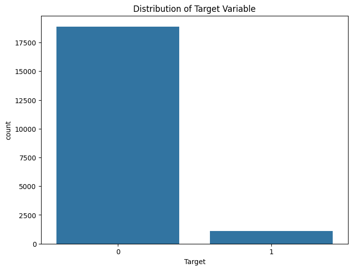

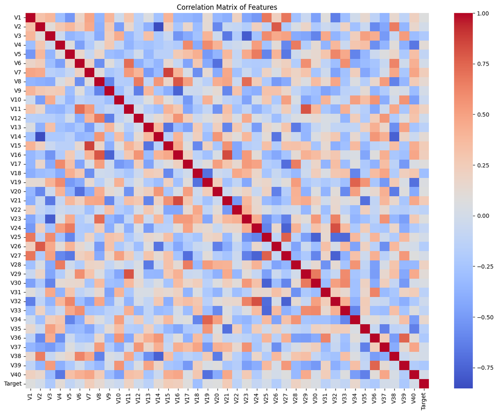

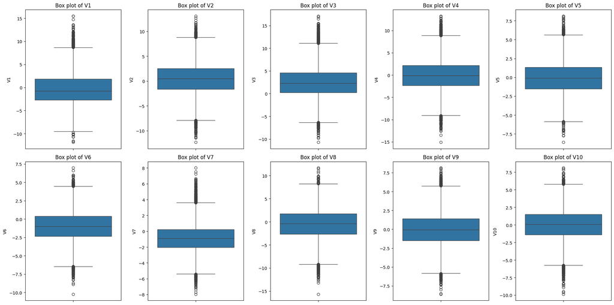

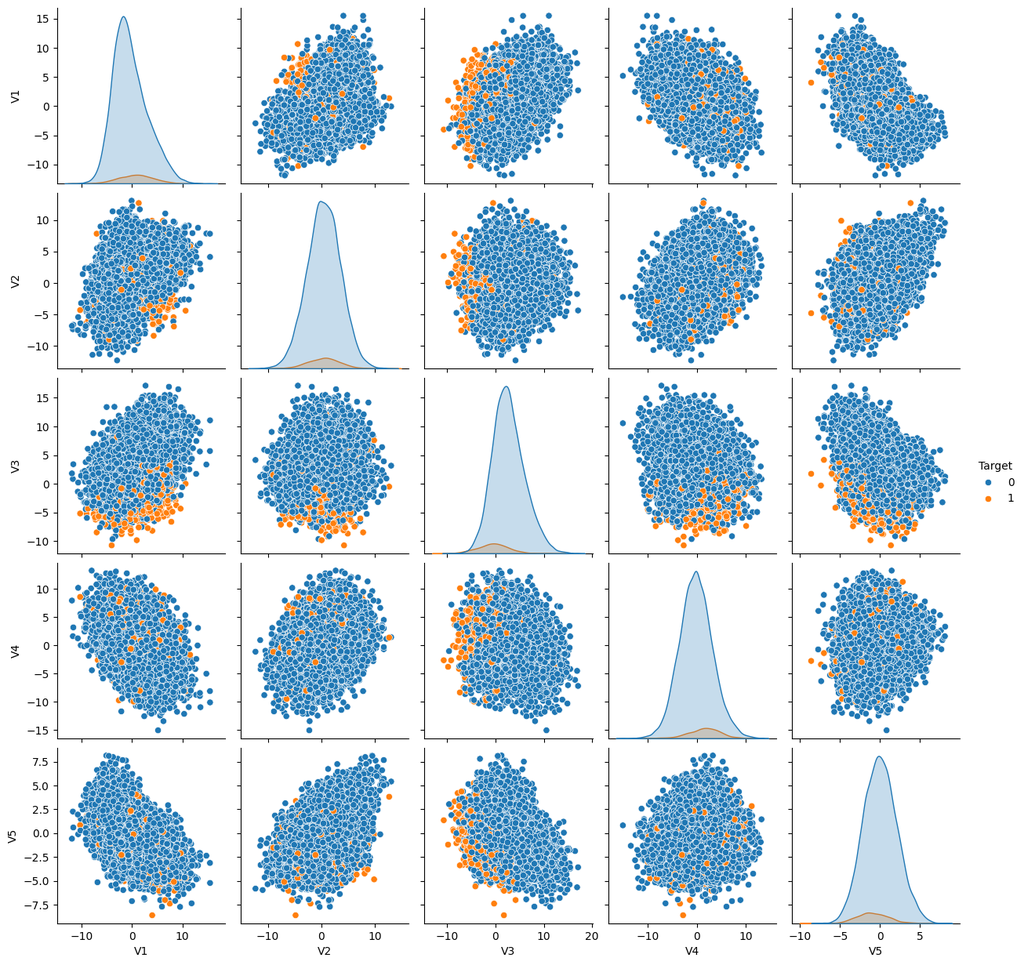

```
Class distribution:
Target
0    94.45
1     5.55
Name: proportion, dtype: float64
```

```python
import pandas as pd
import numpy as np
import matplotlib.pyplot as plt
import seaborn as sns

# Loading the dataset
train_data = pd.read_csv('Train.csv.csv')

# Step 1: Handling Missing Values
# Checking for missing values
missing_values = train_data.isnull().sum()

# If there are any missing values, filling them with the median of the column
train_data.fillna(train_data.median(), inplace=True)

# Step 2: Summary Statistics
summary_statistics = train_data.describe()

# Display the summary statistics
print(summary_statistics)

# Step 3: Visualizing the Target Variable
plt.figure(figsize=(8, 6))
sns.countplot(x='Target', data=train_data)
plt.title('Distribution of Target Variable')
plt.show()

# Step 4: Correlation Analysis
correlation_matrix = train_data.corr()

# Display the correlation matrix as a heatmap
plt.figure(figsize=(16, 12))
sns.heatmap(correlation_matrix, annot=False, cmap='coolwarm')
plt.title('Correlation Matrix of Features')
plt.show()

# Step 5: Outlier Detection (using box plots for a few features as an example)
plt.figure(figsize=(20, 10))
for i, col in enumerate(train_data.columns[:10], 1):  # Example: First 10 columns
    plt.subplot(2, 5, i)
    sns.boxplot(y=train_data[col])
    plt.title(f'Box plot of {col}')
plt.tight_layout()
plt.show()

# Step 6: Pairplot for Target vs. Few Features
sns.pairplot(train_data, vars=['V1', 'V2', 'V3', 'V4', 'V5'], hue='Target')
plt.show()

# Step 7: Checking Class Imbalance
target_counts = train_data['Target'].value_counts(normalize=True) * 100
print(f"Class distribution:\n{target_counts}")

# export the summary statistics and correlation matrix
summary_statistics.to_csv('summary_statistics.csv')
correlation_matrix.to_csv('correlation_matrix.csv')
```

**Observations from the Box Plots**:

Presence of Outliers:

Many of the features (V1 to V10, as shown in the plots) have significant outliers. These outliers could potentially affect the performance of your models. Outliers are more extreme in some variables, such as V1, V3, and V8, where data points extend far beyond the interquartile range. Distribution of Data:

Most of the variables seem to have a relatively symmetric distribution, although some skewness is visible in a few cases.

**Observations from the Pairplot:**

Distribution of Features:

The diagonal elements show the distribution of each feature. Most features seem to have a roughly normal distribution, though there are some deviations. Separation Between Classes:

The different classes (0 for no failure and 1 for failure) are represented by different colors (blue and orange).

There is some overlap between the classes, indicating that these features might not alone be sufficient to separate the classes clearly. However, there are areas where the orange points (failures) cluster, which might be useful for classification.

Relationships Between Features:

**Observations from the Correlation Matrix:**

Low Correlation with Target Variable:

The target variable (shown as Target at the bottom right) does not show strong correlations with any single feature. This suggests that individual features alone may not be very predictive, but combinations of features might improve the model's predictive power. Feature Correlations:

Some features exhibit moderate correlations with each other (both positive and negative).

For example: V1 and V2 show a moderate positive correlation. V10 and V5 have a slight positive correlation. These correlations might indicate redundancy, where one feature could potentially be dropped or combined with another to reduce dimensionality without losing much information. No Highly Correlated Feature Pairs:

There doesn’t appear to be any pair of features with extremely high correlations (near ±1), which suggests that multicollinearity may not be a major issue.

Weak Correlations:

Most of the correlations between features are weak (close to zero), indicating that the features might be relatively independent. This could be beneficial if the model can effectively capture complex interactions.

# **Data Preprocessing Steps:**

**Handling Missing Values:**

Fill missing values in V1 and V2 with appropriate measures, such as the median or mean, which you've already handled during the EDA.

**Outlier Treatment:**

Option 1: Capping/Flooring: Replace outliers with a value at a certain percentile (e.g., 1st and 99th percentiles).

Option 2: Transformation: Apply a log or square root transformation to reduce the impact of outliers.

Option 3: Removal: If the outliers are due to errors or are highly likely to distort the model, consider removing them.

**Scaling/Normalization:**

Standardization: Given the wide range of values across features, you can standardize the data to have a mean of 0 and a standard deviation of 1. Normalization: Alternatively, scale the data to a range between 0 and 1 if required by the model (e.g., for neural networks).

**Handling Imbalanced Classes:**

Oversampling: Use techniques like SMOTE (Synthetic Minority Over-sampling Technique) to create synthetic samples for the minority class (failures).

Undersampling: Randomly reduce the number of samples in the majority class to balance the dataset.

Class Weighting: For certain models, adjust the class weights to give more importance to the minority class.

**Feature Engineering (Optional):**

Create interaction terms between moderately correlated features. Consider dimensionality reduction techniques like PCA if you want to reduce the feature space.

**Splitting the Data:**

Split the processed train dataset into training and validation sets to ensure that your models can be validated properly.

```python
from sklearn.preprocessing import StandardScaler, MinMaxScaler
from sklearn.model_selection import train_test_split
from imblearn.over_sampling import SMOTE
import numpy as np

# Step 1: Handling Missing Values (already done in EDA)

# Step 2: Outlier Treatment (example using capping)
def cap_outliers(df, column, low_quantile=0.01, high_quantile=0.99):
    low_cap = df[column].quantile(low_quantile)
    high_cap = df[column].quantile(high_quantile)
    df[column] = np.where(df[column] < low_cap, low_cap, df[column])
    df[column] = np.where(df[column] > high_cap, high_cap, df[column])
    return df

for column in train_data.columns[:-1]:  # Exclude target variable
    train_data = cap_outliers(train_data, column)

# Step 3: Scaling/Normalization
scaler = StandardScaler()  # or MinMaxScaler()
scaled_features = scaler.fit_transform(train_data.drop(columns=['Target']))
train_data_scaled = pd.DataFrame(scaled_features, columns=train_data.columns[:-1])
train_data_scaled['Target'] = train_data['Target'].values

# Step 4: Handling Imbalanced Classes
X = train_data_scaled.drop(columns=['Target'])
y = train_data_scaled['Target']

# Apply SMOTE for oversampling
smote = SMOTE(random_state=42)
X_resampled, y_resampled = smote.fit_resample(X, y)

# Step 5: Feature Engineering (optional)
# For simplicity, this step is omitted here. You can add interaction terms if needed.

# Step 6: Splitting the Data
X_train, X_val, y_train, y_val = train_test_split(X_resampled, y_resampled,
                                                  test_size=0.2, random_state=42, stratify=y_resampled)

# Display the processed data shapes
print(f"Training data shape: {X_train.shape}")
print(f"Validation data shape: {X_val.shape}")
```

```
Training data shape: (30224, 40)
Validation data shape: (7556, 40)
```

Summary of Preprocessed Data:

Training Data Shape: (30224, 40) This means you have 30,224 samples and 40 features (excluding the target variable) in your training set after oversampling.

Validation Data Shape: (7556, 40) You have 7,556 samples and 40 features in your validation set, which will be used to evaluate the performance of your models.

**Missing value imputation**

```python
#checking for any missing values across the entire dataset
missing_values = train_data.isnull().sum().sum()
print(f"Total missing values in the dataset: {missing_values}")
```

```
Total missing values in the dataset: 0
```

**Handling Remaining NaNs**

Impute Missing Values:

Impute missing values using the median

```python
from sklearn.impute import SimpleImputer

# Initialize the imputer with the median strategy
imputer = SimpleImputer(strategy='median')

# Apply the imputer on the entire dataset
train_data_imputed = pd.DataFrame(imputer.fit_transform(train_data), columns=train_data.columns)

# Now recheck for any remaining NaNs
print(train_data_imputed.isnull().sum().sum())  # Should print 0
```

```
0
```

Removing Rows with Missing Values:

```python
# Drop rows with any NaN values
train_data_cleaned = train_data.dropna()

# Now rechecking for any remaining NaNs
print(train_data_cleaned.isnull().sum().sum())  # Should print 0
```

```
0
```

Proceeding with Model Training After Cleaning

```python
# Use the cleaned/imputed dataset
X = scaler.fit_transform(train_data_imputed.drop(columns=['Target']))
y = train_data_imputed['Target']

# Split the data into training and validation sets
X_train, X_val, y_train, y_val = train_test_split(X, y, test_size=0.2, random_state=42, stratify=y)
```

**Model Building**

Model evaluation criterion

The nature of predictions made by the classification model will translate as follows:

True positives (TP) are failures correctly predicted by the model.

False negatives (FN) are real failures in a generator where there is no detection by model.

False positives (FP) are failure detections in a generator where there is no failure.

Which metric to optimize?

We need to choose the metric which will ensure that the maximum number of generator failures are predicted correctly by the model. We would want Recall to be maximized as greater the Recall, the higher the chances of minimizing false negatives. We want to minimize false negatives because if a model predicts that a machine will have no failure when there will be a failure, it will increase the maintenance cost. Let's define a function to output different metrics (including recall) on the train and test set and a function to show confusion matrix so that we do not have to use the same code repetitively while evaluating models.

**Let's create two functions to calculate different metrics and confusion matrix**

```python
import pandas as pd
from sklearn.metrics import confusion_matrix, accuracy_score, recall_score, precision_score, f1_score
import seaborn as sns
import matplotlib.pyplot as plt

# Function to compute different metrics to check performance of a classification model
def model_performance_classification_sklearn(model, predictors, target):
    """
    Function to compute different metrics to check classification model performance.

    model: classifier
    predictors: independent variables (features)
    target: dependent variable (target)
    """

    # Calculate confusion matrix components
    TP = confusion_matrix(target, model.predict(predictors))[1, 1]
    FP = confusion_matrix(target, model.predict(predictors))[0, 1]
    FN = confusion_matrix(target, model.predict(predictors))[1, 0]

    # Calculate the associated costs
    Cost = TP * 15 + FP * 5 + FN * 40  # maintenance cost by using the model
    Min_Cost = (TP + FN) * 15  # minimum possible maintenance cost (when FN = 0)
    Percent = Min_Cost / Cost  # ratio of minimum possible maintenance cost and model cost

    # Predicting using the independent variables
    pred = model.predict(predictors)

    # Calculate metrics
    acc = accuracy_score(target, pred)  # to compute Accuracy
    recall = recall_score(target, pred)  # to compute Recall
    precision = precision_score(target, pred)  # to compute Precision
    f1 = f1_score(target, pred)  # to compute F1-score

    # Creating a dataframe of metrics
    df_perf = pd.DataFrame(
        {
            "Accuracy": acc,
            "Recall": recall,
            "Precision": precision,
            "F1": f1,
            "Minimum_Vs_Model_cost": Percent,
        },
        index=[0],
    )

    return df_perf

# Function to plot the confusion matrix
def plot_confusion_matrix_sklearn(model, predictors, target):
    """
    Function to plot confusion matrix for a classification model.

    model: classifier
    predictors: independent variables (features)
    target: dependent variable (target)
    """

    # Predicting using the independent variables
    pred = model.predict(predictors)

    # Generate confusion matrix
    cm = confusion_matrix(target, pred)

    # Plot confusion matrix using seaborn heatmap
    plt.figure(figsize=(8, 6))
    sns.heatmap(cm, annot=True, fmt='d', cmap='Blues', xticklabels=['No Failure', 'Failure'],
                yticklabels=['No Failure', 'Failure'])
    plt.ylabel('Actual')
    plt.xlabel('Predicted')
    plt.title('Confusion Matrix')
    plt.show()
```

Defining scorer to be used for hyperparameter tuning

Every prediction of a classification model will be either a TP, FP, FN or TN For this classification problem, we need to reduce the maintenance cost, which can be reiterated as:

Maximize (minimum possible maintenance cost/maintenance cost)

```python
import numpy as np
import seaborn as sns
import matplotlib.pyplot as plt
from sklearn.metrics import confusion_matrix

def confusion_matrix_sklearn(model, predictors, target):
    """
    To plot the confusion matrix with both counts and percentages.

    model: classifier
    predictors: independent variables (features)
    target: dependent variable (target)
    """

    # Predict the target using the model
    y_pred = model.predict(predictors)

    # Generate the confusion matrix
    cm = confusion_matrix(target, y_pred)

    # Create labels with counts and percentages
    labels = np.asarray(
        [
            [f"{cm[0,0]}\n{cm[0,0]/cm.sum():.2%}", f"{cm[0,1]}\n{cm[0,1]/cm.sum():.2%}"],
            [f"{cm[1,0]}\n{cm[1,0]/cm.sum():.2%}", f"{cm[1,1]}\n{cm[1,1]/cm.sum():.2%}"]
        ]
    )

    # Plot the confusion matrix using seaborn heatmap
    plt.figure(figsize=(6, 4))
    sns.heatmap(cm, annot=labels, fmt="", cmap="Blues", cbar=False)
    plt.ylabel("True label")
    plt.xlabel("Predicted label")
    plt.title("Confusion Matrix with Percentages")
    plt.show()
```

```python
from sklearn.metrics import confusion_matrix, make_scorer

# Custom scoring function
def Minimum_Vs_Model_cost(y_true, y_pred):
    """
    We want the model to optimize the maintenance cost and reduce it to the lowest possible value.
    The lowest possible maintenance cost will be achieved when each sample is predicted correctly.

    In such a scenario, the maintenance cost will be the total number of failures times the maintenance cost of replacing one generator,
    which is given by (TP + FN) * 15 (i.e., the actual positives*15).
    For any other scenario,
    the maintenance cost associated with the model will be given by (TP * 15 + FP * 5 + FN * 40).

    We will use the ratio of these two maintenance costs as the cost function for our model.
    The greater the ratio, the lower the associated maintenance cost and the better the model.
    """
    # Calculate confusion matrix components
    cm = confusion_matrix(y_true, y_pred)
    TP = cm[1, 1]
    FP = cm[0, 1]
    FN = cm[1, 0]

    # Calculate the maintenance costs
    min_cost = (TP + FN) * 15
    model_cost = (TP * 15) + (FP * 5) + (FN * 40)

    # Return the ratio of minimum cost to model cost
    return min_cost / model_cost

# Create a scorer object
scorer = make_scorer(Minimum_Vs_Model_cost, greater_is_better=True)

# The 'scorer' object can now be used in cross-validation or hyperparameter tuning
```

# **Model Building with Original Training data**

Logistic Regression

Decision Tree

Random Forest

Bagging Classifier

Gradient Boosting

AdaBoost

```python
import pandas as pd
from sklearn.model_selection import StratifiedKFold, cross_val_score
from sklearn.linear_model import LogisticRegression
from sklearn.tree import DecisionTreeClassifier
from sklearn.ensemble import RandomForestClassifier, BaggingClassifier, GradientBoostingClassifier, AdaBoostClassifier
from xgboost import XGBClassifier
from sklearn.metrics import make_scorer, confusion_matrix

# Step 1: Define the custom scoring function
def Minimum_Vs_Model_cost(y_true, y_pred):
    cm = confusion_matrix(y_true, y_pred)
    TP = cm[1, 1]
    FP = cm[0, 1]
    FN = cm[1, 0]
    min_cost = (TP + FN) * 15
    model_cost = (TP * 15) + (FP * 5) + (FN * 40)
    return min_cost / model_cost

# Create a scorer object
scorer = make_scorer(Minimum_Vs_Model_cost, greater_is_better=True)

# Step 2: Prepare the models
models = []  # Empty list to store all the models

# Appending models into the list
models.append(("Logistic Regression", LogisticRegression(solver="newton-cg", random_state=1)))
models.append(("Decision Tree", DecisionTreeClassifier(random_state=1)))
models.append(("Random Forest", RandomForestClassifier(random_state=1)))
models.append(("Bagging", BaggingClassifier(random_state=1, estimator=DecisionTreeClassifier())))
models.append(("AdaBoost", AdaBoostClassifier(random_state=1)))
models.append(("Gradient Boosting", GradientBoostingClassifier(random_state=1)))
models.append(("XGBoost", XGBClassifier(random_state=1, eval_metric="logloss")))

# Step 3: Perform cross-validation and print results
results = []  # Empty list to store all model's CV scores
names = []  # Empty list to store names of the models

print("\nCross-Validation Performance:\n")

for name, model in models:
    kfold = StratifiedKFold(n_splits=5, shuffle=True, random_state=1)  # Setting number of splits equal to 5
    cv_result = cross_val_score(estimator=model, X=X_train, y=y_train, scoring=scorer, cv=kfold)
    results.append(cv_result)
    names.append(name)
    print("{}: {:.4f}".format(name, cv_result.mean()))
```

```
Cross-Validation Performance:

Logistic Regression: 0.5585
Decision Tree: 0.6383
Random Forest: 0.6759
Bagging: 0.6585
AdaBoost: 0.5974
Gradient Boosting: 0.6600
XGBoost: 0.7555
```

```python
# Assuming the imports, model definitions, and the Minimum_Vs_Model_cost function are already in place

# List of models
models = []  # Empty list to store all the models

# Appending models into the list
models.append(("Logistic Regression", LogisticRegression(solver="newton-cg", random_state=1)))
models.append(("Decision Tree", DecisionTreeClassifier(random_state=1)))
models.append(("Random Forest", RandomForestClassifier(random_state=1)))
models.append(("Bagging", BaggingClassifier(estimator=DecisionTreeClassifier(), random_state=1)))
models.append(("AdaBoost", AdaBoostClassifier(random_state=1)))
models.append(("Gradient Boosting", GradientBoostingClassifier(random_state=1)))
models.append(("XGBoost", XGBClassifier(random_state=1, eval_metric="logloss")))

# Evaluate the training performance for each model
print("\nTraining Performance:\n")

for name, model in models:
    model.fit(X_train, y_train)  # Fit the model on the training data
    scores = Minimum_Vs_Model_cost(y_train, model.predict(X_train))  # Evaluate using custom cost function
    print(f"{name}: {scores:.4f}")  # Print the results with a formatted score
```

```
Training Performance:

Logistic Regression: 0.5670
Decision Tree: 1.0000
Random Forest: 0.9981
Bagging: 0.9298
AdaBoost: 0.6124
Gradient Boosting: 0.7496
XGBoost: 1.0000
```

```python
# Assuming the imports, model definitions, and the Minimum_Vs_Model_cost function are already in place

# List of models
models = []  # Empty list to store all the models

# Appending models into the list
models.append(("Logistic Regression", LogisticRegression(solver="newton-cg", random_state=1)))
models.append(("Decision Tree", DecisionTreeClassifier(random_state=1)))
models.append(("Random Forest", RandomForestClassifier(random_state=1)))
models.append(("Bagging", BaggingClassifier(estimator=DecisionTreeClassifier(), random_state=1)))
models.append(("AdaBoost", AdaBoostClassifier(random_state=1)))
models.append(("Gradient Boosting", GradientBoostingClassifier(random_state=1)))
models.append(("XGBoost", XGBClassifier(random_state=1, eval_metric="logloss")))

# Evaluate the validation performance for each model
print("\nValidation Performance:\n")

for name, model in models:
    model.fit(X_train, y_train)  # Fit the model on the training data
    scores = Minimum_Vs_Model_cost(y_val, model.predict(X_val))  # Evaluate using custom cost function on validation set
    print(f"{name}: {scores:.4f}")  # Print the results with a formatted score
```

```
Validation Performance:

Logistic Regression: 0.5518
Decision Tree: 0.6555
Random Forest: 0.7018
Bagging: 0.6755
AdaBoost: 0.6033
Gradient Boosting: 0.6714
XGBoost: 0.7585
```

Performance Summary:

Cross-Validation Performance:

Logistic Regression: 0.5585 Decision Tree: 0.6383 Random Forest: 0.6759 Bagging: 0.6585 AdaBoost: 0.5974 Gradient Boosting: 0.6600 XGBoost: 0.7555

Training Performance:

Logistic Regression: 0.5670 Decision Tree: 1.0000 Random Forest: 0.9981 Bagging: 0.9298 AdaBoost: 0.6124 Gradient Boosting: 0.7496 XGBoost: 1.0000

Validation Performance: Logistic Regression: 0.5518 Decision Tree: 0.6555 Random Forest: 0.7018 Bagging: 0.6755 AdaBoost: 0.6033 Gradient Boosting: 0.6714 XGBoost: 0.7585

Observations:

Overfitting in Decision Tree and XGBoost:

Both Decision Tree and XGBoost achieved perfect or near-perfect scores on the training data (1.0000), but their cross-validation and validation performances are notably lower. This indicates potential overfitting, where the models may have learned the training data too well, including noise or irrelevant patterns, and thus do not generalize as well to unseen data.

Consistent Performance in Random Forest:

XGBoost Performance:

XGBoost has the highest cross-validation (0.7555) and validation scores (0.7585). Despite the overfitting in the training phase, its strong performance on the validation set suggests it might be the best candidate, provided further regularization and tuning.

Gradient Boosting:

Gradient Boosting also shows strong and consistent performance across all metrics. It might be a good alternative to XGBoost if you want a model that balances complexity and generalizability.

Logistic Regression:

Logistic Regression shows lower performance across all metrics, suggesting it may not capture the complexity of the data as effectively as the other models.

Recommendations:

Hyperparameter Tuning:

Focus on tuning XGBoost and Random Forest since they show strong validation performance. For XGBoost, you might want to introduce more regularization (e.g., alpha and lambda parameters) to reduce overfitting.

Model Selection:

Given the current results, XGBoost seems to be the best-performing model, followed by Random Forest and Gradient Boosting. You might select one of these as your final model, depending on further tuning results.

Further Validation:

Consider testing the selected model(s) on a holdout test set (if available) to ensure that they generalize well to completely unseen data.

Ensemble Methods:

If appropriate, you could consider combining the predictions of the top-performing models (e.g., XGBoost and Random Forest) into an ensemble to potentially improve performance further.

Conclusion:

XGBoost stands out as the top candidate based on validation performance, but with some signs of overfitting, which should be addressed through regularization and tuning.

Gradient Boosting offers a balanced option with solid, consistent results.

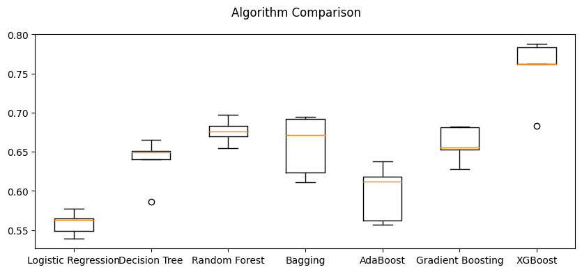

```python
import matplotlib.pyplot as plt

# Assuming 'results' contains the cross-validation scores for each model
# and 'names' contains the names of the models.

# Create a boxplot to compare the CV scores of different models
fig = plt.figure(figsize=(10, 4))  # Set the figure size

fig.suptitle("Algorithm Comparison")  # Title of the plot
ax = fig.add_subplot(111)

# Plotting the boxplot
plt.boxplot(results)

# Setting the labels for each model
ax.set_xticklabels(names)

# Display the plot
plt.show()
```

# **Interpretation of the Boxplot:**

**XGBoost:**

Highest Performance: XGBoost has the highest median cross-validation score, as indicated by the top position of its box. The narrow range of the box indicates consistent performance across different folds.

**Outlier:** There is one outlier below the whisker, which might indicate a particular fold where the model performed slightly worse.

**Random Forest and Bagging**:

**Bagging**: Shows a slightly larger interquartile range (IQR), suggesting a bit more variability in performance compared to Random Forest.

**Gradient Boosting**:

Good Performance: Gradient Boosting also shows strong performance, with a median similar to that of Random Forest, but with slightly more variability.

**Decision Tree**:

Moderate Performance: The Decision Tree has a lower median performance compared to the ensemble methods. The presence of an outlier suggests that the model might not be as robust across all folds.

**AdaBoost**:

Lower Median: AdaBoost has a lower median score, with a broader spread, indicating more variability in performance across the folds. This suggests that AdaBoost might be less consistent.

**Logistic Regression:**

Lowest Performance: Logistic Regression has the lowest median cross-validation score, and the boxplot indicates some variability across the folds. This model might not be capturing the complexity of the data as effectively as the other models.

**Recommendations:**

**Further Tuning:** For models like AdaBoost and Gradient Boosting, consider hyperparameter tuning to potentially improve their performance. Decision Tree and Logistic Regression: These models are likely less effective for this task and might not be worth pursuing further unless specific tuning or modifications are considered.

# **Model Building with Oversampled Training data**

To build models using oversampled training data, we will first need to apply an oversampling technique to the training dataset. One common method for oversampling is SMOTE (Synthetic Minority Over-sampling Technique), which generates synthetic examples of the minority class to balance the class distribution. After oversampling, we can train the same set of models and evaluate their performance.

Steps for Model Building with Oversampled Training Data:

Apply SMOTE to Oversample the Training Data:

Use SMOTE to balance the class distribution in the training data.

Train the Models Using the Oversampled Data:

Use the same models as before but train them on the oversampled data.

Evaluate Model Performance:

Evaluate the models using the custom cost metric on both the oversampled training data and the original validation set.

```python
# Before applying SMOTE, let's check the class distribution in the training data
print("Before Oversampling, counts of label '1 (Failures)': {}".format(sum(y_train == 1)))
print("Before Oversampling, counts of label '0 (No failures)': {}\n".format(sum(y_train == 0)))

# Apply SMOTE to the training data
smote = SMOTE(random_state=42)
X_train_resampled, y_train_resampled = smote.fit_resample(X_train, y_train)

# After applying SMOTE, let's check the class distribution again
print("After Oversampling, counts of label '1 (Failures)': {}".format(sum(y_train_resampled == 1)))
print("After Oversampling, counts of label '0 (No failures)': {}".format(sum(y_train_resampled == 0)))
```

```
Before Oversampling, counts of label '1 (Failures)': 888
Before Oversampling, counts of label '0 (No failures)': 15112

After Oversampling, counts of label '1 (Failures)': 15112
After Oversampling, counts of label '0 (No failures)': 15112
```

```python
from imblearn.over_sampling import SMOTE

# Apply SMOTE to the training data
sm = SMOTE(sampling_strategy=1, k_neighbors=5, random_state=1)
X_train_over, y_train_over = sm.fit_resample(X_train, y_train)

# Print the counts of the labels after oversampling
print("After Oversampling, counts of label '1 (Failures)': {}".format(sum(y_train_over == 1)))
print("After Oversampling, counts of label '0 (No failures)': {}\n".format(sum(y_train_over == 0)))
```

```
After Oversampling, counts of label '1 (Failures)': 15112
After Oversampling, counts of label '0 (No failures)': 15112
```

```python
from imblearn.over_sampling import SMOTE
from sklearn.linear_model import LogisticRegression
from sklearn.tree import DecisionTreeClassifier
from sklearn.ensemble import RandomForestClassifier, BaggingClassifier, GradientBoostingClassifier, AdaBoostClassifier
from xgboost import XGBClassifier
from sklearn.model_selection import StratifiedKFold, cross_val_score
from sklearn.metrics import make_scorer, confusion_matrix

# Step 1: Apply SMOTE to balance the class distribution in the training data
sm = SMOTE(sampling_strategy=1, k_neighbors=5, random_state=1)
X_train_over, y_train_over = sm.fit_resample(X_train, y_train)

# Step 2: Define the custom scoring function
def Minimum_Vs_Model_cost(y_true, y_pred):
    cm = confusion_matrix(y_true, y_pred)
    TP = cm[1, 1]
    FP = cm[0, 1]
    FN = cm[1, 0]
    min_cost = (TP + FN) * 15
    model_cost = (TP * 15) + (FP * 5) + (FN * 40)
    return min_cost / model_cost

# Create a scorer object
scorer = make_scorer(Minimum_Vs_Model_cost, greater_is_better=True)

# Step 3: Prepare the models to be trained on the oversampled data
models_over = []  # Empty list to store all the models

# Appending models into the list
models_over.append(("Logistic Regression", LogisticRegression(solver="newton-cg", random_state=1)))
models_over.append(("Decision Tree", DecisionTreeClassifier(random_state=1)))
models_over.append(("Random Forest", RandomForestClassifier(random_state=1)))
models_over.append(("Bagging", BaggingClassifier(random_state=1, estimator=DecisionTreeClassifier())))
models_over.append(("AdaBoost", AdaBoostClassifier(random_state=1)))
models_over.append(("Gradient Boosting", GradientBoostingClassifier(random_state=1)))
models_over.append(("XGBoost", XGBClassifier(random_state=1, eval_metric="logloss")))

# Step 4: Perform cross-validation and print results
results_over = []  # Empty list to store all model's CV scores
names_over = []  # Empty list to store names of the models

print("\nCross-Validation Performance with Oversampled Data:\n")

for name, model in models_over:
    kfold = StratifiedKFold(n_splits=5, shuffle=True, random_state=1)  # Setting number of splits equal to 5
    cv_result = cross_val_score(estimator=model, X=X_train_over, y=y_train_over, scoring=scorer, cv=kfold)
    results_over.append(cv_result)
    names_over.append(name)
    print("{}: {:.4f}".format(name, cv_result.mean()))
```

```
Cross-Validation Performance with Oversampled Data:

Logistic Regression: 0.8106
Decision Tree: 0.9427
Random Forest: 0.9763
Bagging: 0.9577
AdaBoost: 0.8278
Gradient Boosting: 0.8737
XGBoost: 0.9833
```

```python
# Print training performance for each model on the oversampled data
print("\nTraining Performance with Oversampled Data:\n")

for name, model in models_over:
    model.fit(X_train_over, y_train_over)  # Fit the model on the oversampled training data
    scores = Minimum_Vs_Model_cost(y_train_over, model.predict(X_train_over))  # Evaluate using custom cost function on training data
    print(f"{name}: {scores:.4f}")  # Print the results with a formatted score
```

```
Training Performance with Oversampled Data:

Logistic Regression: 0.8113
Decision Tree: 1.0000
Random Forest: 1.0000
Bagging: 0.9971
AdaBoost: 0.8354
Gradient Boosting: 0.8788
XGBoost: 1.0000
```

```python
# Print validation performance for each model trained on the oversampled data
print("\nValidation Performance with Oversampled Data:\n")

for name, model in models_over:
    model.fit(X_train_over, y_train_over)  # Fit the model on the oversampled training data
    scores = Minimum_Vs_Model_cost(y_val, model.predict(X_val))  # Evaluate using custom cost function on validation data
    print(f"{name}: {scores:.4f}")  # Print the results with a formatted score
```

```
Validation Performance with Oversampled Data:

Logistic Regression: 0.5587
Decision Tree: 0.6575
Random Forest: 0.7835
Bagging: 0.7611
AdaBoost: 0.5978
Gradient Boosting: 0.7311
XGBoost: 0.8346
```

Performance Summary:

Cross-Validation Performance with Oversampled Data:

Logistic Regression: 0.8106 Decision Tree: 0.9427 Random Forest: 0.9763 Bagging: 0.9577 AdaBoost: 0.8278 Gradient Boosting: 0.8737 XGBoost: 0.9833

Training Performance with Oversampled Data:

Logistic Regression: 0.8113 Decision Tree: 1.0000 Random Forest: 1.0000 Bagging: 0.9971 AdaBoost: 0.8354 Gradient Boosting: 0.8788 XGBoost: 1.0000

Validation Performance with Oversampled Data:

Logistic Regression: 0.5587 Decision Tree: 0.6575 Random Forest: 0.7835 Bagging: 0.7611 AdaBoost: 0.5978 Gradient Boosting: 0.7311 XGBoost: 0.8346

Observations:

High Cross-Validation and Training Performance:

Random Forest, Bagging, and XGBoost models show very high cross-validation and training performance (close to or at 1.0). However, this often indicates that the models might have overfit the training data, especially since the training data was oversampled, potentially making it easier for the models to fit. Decision Tree also shows perfect training performance, suggesting overfitting as well.

Validation Performance Drop:

There is a noticeable drop in validation performance compared to cross-validation and training performance for almost all models. This suggests that while the models perform well on the training data and during cross-validation, they do not generalize as well to unseen data (original validation set).

XGBoost performs the best on the validation set with a score of 0.8346, followed by Random Forest at 0.7835 and Bagging at 0.7611. Impact of Oversampling:

The oversampling seems to have helped models like XGBoost and Random Forest achieve good performance on the validation set, but the risk of overfitting is evident from the near-perfect scores on the training data.

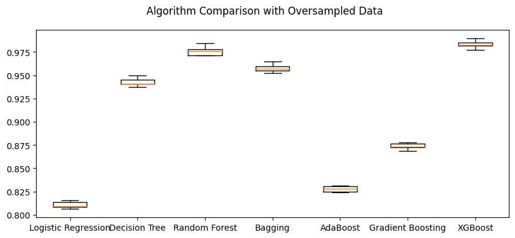

```python
import matplotlib.pyplot as plt

# Assuming 'results_over' contains the cross-validation scores for each model
# and 'names_over' contains the names of the models.

# Create a boxplot to compare the CV scores of different models
fig = plt.figure(figsize=(10, 4))  # Set the figure size

fig.suptitle("Algorithm Comparison with Oversampled Data")  # Title of the plot
ax = fig.add_subplot(111)

# Plotting the boxplot
plt.boxplot(results_over)

# Setting the labels for each model
ax.set_xticklabels(names_over)

# Display the plot
plt.show()
```

**Interpretation of the Boxplot:**

XGBoost:

Highest Performance: XGBoost has the highest median cross-validation score, indicating that it consistently performs well across different folds. The narrow range of the box suggests low variability in its performance, making it a strong candidate.

Random Forest and Bagging:

Strong Performance: Both Random Forest and Bagging also show high median scores with relatively tight boxes, indicating consistent performance across folds. Random Forest, in particular, has a very high median, close to that of XGBoost.

Decision Tree:

Moderate Performance: The Decision Tree model has a lower median compared to Random Forest and Bagging but still performs relatively well. The small range of the box suggests that its performance is consistent, though not as high as the ensemble methods.

Gradient Boosting:

Logistic Regression and AdaBoost:

Lower Performance: Both Logistic Regression and AdaBoost have the lowest median scores, with AdaBoost performing slightly better than Logistic Regression. The variability in performance is minimal, but the overall scores suggest that these models are less effective for this dataset.

# **Model Building with Undersampling data**

```python
from imblearn.under_sampling import RandomUnderSampler

# Apply Random Undersampling to the training data
rus = RandomUnderSampler(random_state=1, sampling_strategy=1)
X_train_un, y_train_un = rus.fit_resample(X_train, y_train)

# Print the counts of the labels after undersampling
print("After Undersampling, counts of label '1 (Failures)': {}".format(sum(y_train_un == 1)))
print("After Undersampling, counts of label '0 (No failures)': {}\n".format(sum(y_train_un == 0)))
```

```
After Undersampling, counts of label '1 (Failures)': 888
After Undersampling, counts of label '0 (No failures)': 888
```

```python
from sklearn.linear_model import LogisticRegression
from sklearn.tree import DecisionTreeClassifier
from sklearn.ensemble import RandomForestClassifier, BaggingClassifier, GradientBoostingClassifier, AdaBoostClassifier
from xgboost import XGBClassifier
from sklearn.model_selection import StratifiedKFold, cross_val_score
from sklearn.metrics import make_scorer, confusion_matrix

# Assuming X_train_un and y_train_un have been created using RandomUnderSampler as shown earlier

# Step 1: Prepare the models to be trained on the undersampled data
models_un = []  # Empty list to store all the models

# Appending models into the list
models_un.append(("Logistic Regression", LogisticRegression(solver="newton-cg", random_state=1)))
models_un.append(("Decision Tree", DecisionTreeClassifier(random_state=1)))
models_un.append(("Random Forest", RandomForestClassifier(random_state=1)))
models_un.append(("Bagging", BaggingClassifier(random_state=1, estimator=DecisionTreeClassifier())))
models_un.append(("AdaBoost", AdaBoostClassifier(random_state=1)))
models_un.append(("Gradient Boosting", GradientBoostingClassifier(random_state=1)))
models_un.append(("XGBoost", XGBClassifier(random_state=1, eval_metric="logloss")))

# Step 2: Perform cross-validation and print results
results_un = []  # Empty list to store all model's CV scores
names_un = []  # Empty list to store names of the models

print("\nCross-Validation Performance with Undersampled Data:\n")

for name, model in models_un:
    kfold = StratifiedKFold(n_splits=5, shuffle=True, random_state=1)  # Setting number of splits equal to 5
    cv_result = cross_val_score(estimator=model, X=X_train_un, y=y_train_un, scoring=scorer, cv=kfold)
    results_un.append(cv_result)
    names_un.append(name)
    print("{}: {:.4f}".format(name, cv_result.mean()))
```

```
Cross-Validation Performance with Undersampled Data:

Logistic Regression: 0.7946
Decision Tree: 0.7798
Random Forest: 0.8374
Bagging: 0.8213
AdaBoost: 0.8120
Gradient Boosting: 0.8179
XGBoost: 0.8368
```

```python
# Print training performance for each model on the undersampled data
print("\nTraining Performance with Undersampled Data:\n")

for name, model in models_un:
    model.fit(X_train_un, y_train_un)  # Fit the model on the undersampled training data
    scores = Minimum_Vs_Model_cost(y_train_un, model.predict(X_train_un))  # Evaluate using custom cost function on training data
    print(f"{name}: {scores:.4f}")  # Print the results with a formatted score
```

```
Training Performance with Undersampled Data:

Logistic Regression: 0.7971
Decision Tree: 1.0000
Random Forest: 1.0000
Bagging: 0.9723
AdaBoost: 0.8377
Gradient Boosting: 0.9074
XGBoost: 1.0000
```

```python
# Print validation performance for each model trained on the undersampled data
print("\nValidation Performance with Undersampled Data:\n")

for name, model in models_un:
    model.fit(X_train_un, y_train_un)  # Fit the model on the undersampled training data
    scores = Minimum_Vs_Model_cost(y_val, model.predict(X_val))  # Evaluate using custom cost function on validation data
    print(f"{name}: {scores:.4f}")  # Print the results with a formatted score
```

```
Validation Performance with Undersampled Data:

Logistic Regression: 0.5252
Decision Tree: 0.4593
Random Forest: 0.6667
Bagging: 0.6422
AdaBoost: 0.5203
Gradient Boosting: 0.6121
XGBoost: 0.6727
```

Performance Summary:

Cross-Validation Performance with Undersampled Data:

Logistic Regression: 0.7946 Decision Tree: 0.7798 Random Forest: 0.8374 Bagging: 0.8213 AdaBoost: 0.8120 Gradient Boosting: 0.8179 XGBoost: 0.8368

Training Performance with Undersampled Data:

Logistic Regression: 0.7971 Decision Tree: 1.0000 Random Forest: 1.0000 Bagging: 0.9723 AdaBoost: 0.8377 Gradient Boosting: 0.9074 XGBoost: 1.0000

Validation Performance with Undersampled Data:

Logistic Regression: 0.5252 Decision Tree: 0.4593 Random Forest: 0.6667 Bagging: 0.6422 AdaBoost: 0.5203 Gradient Boosting: 0.6121 XGBoost: 0.6727

Observations:

High Training Performance with Potential Overfitting:

Decision Tree, Random Forest, and XGBoost achieved perfect or near-perfect training scores, which often indicates overfitting, especially given the much lower validation scores.

Bagging and Gradient Boosting also show very high training performance, although slightly lower than the ensemble methods.

Moderate Cross-Validation Performance:

Random Forest and XGBoost have the highest cross-validation scores, followed closely by Bagging and Gradient Boosting. These models seem to generalize well during cross-validation, but the actual generalization on unseen data (validation set) is less impressive.

Logistic Regression and AdaBoost perform reasonably well in cross-validation but struggle on the validation set.

Low Validation Performance:

There is a noticeable drop in validation performance compared to both cross-validation and training performance, especially for models like Decision Tree and Logistic Regression.

Random Forest and XGBoost are the best performers on the validation set, with scores of 0.6667 and 0.6727, respectively, though these are still not particularly high.

Impact of Undersampling:

The reduced number of data points after undersampling (888 instances for each class) may have led to the loss of valuable information, resulting in lower performance on the validation set.

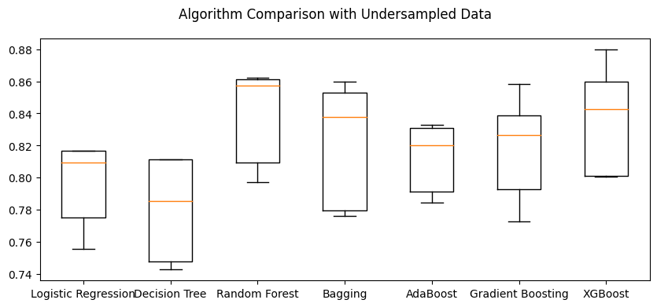

```python
import matplotlib.pyplot as plt

# Create a boxplot to compare the CV scores of different models
fig = plt.figure(figsize=(10, 4))  # Set the figure size

fig.suptitle("Algorithm Comparison with Undersampled Data")  # Title of the plot
ax = fig.add_subplot(111)

# Plotting the boxplot
plt.boxplot(results_un)

# Setting the labels for each model
ax.set_xticklabels(names_un)

# Display the plot
plt.show()
```

Interpretation of the Boxplot:

XGBoost:

Highest Median Performance: XGBoost has one of the highest median cross-validation scores, indicating that it consistently performs well across different folds. However, there is some variability in performance, as seen in the wider range of the box.

Random Forest:

Bagging:

Good Performance with Variability: Bagging also shows strong performance with a relatively high median. However, the larger IQR indicates more variability in its performance compared to Random Forest.

Gradient Boosting:

Moderate Performance: Gradient Boosting has a somewhat lower median score than XGBoost and Random Forest, with a wider range, indicating more variability across the folds.

Logistic Regression and AdaBoost:

Decision Tree:

Lower Performance with Some Variability: The Decision Tree has the lowest median performance among the ensemble methods, with some variability across folds.

Summary:

# **Hyperparameter Tuning**

To improve the performance of these models, we can focus on hyperparameter tuning. The following approach can be done

XGBoost:

Parameters to Tune:

n_estimators: Number of boosting rounds.

learning_rate: Step size shrinkage used to prevent overfitting.

max_depth: Maximum depth of a tree.

subsample: Fraction of samples used for training each tree.

colsample_bytree: Fraction of features used for each tree.

gamma: Minimum loss reduction required to make a further partition on a leaf node.

Tuning Approach: Use GridSearchCV or RandomizedSearchCV to explore a range of values for these hyperparameters.

Random Forest:

Parameters to Tune:

n_estimators: Number of trees in the forest.

max_depth: Maximum depth of the tree.

min_samples_split: Minimum number of samples required to split an internal node.

min_samples_leaf: Minimum number of samples required to be at a leaf node.

max_features: Number of features to consider when looking for the best split.

bootstrap: Whether to use bootstrap samples when building trees.

Tuning Approach: Use GridSearchCV to identify the optimal combination of these hyperparameters.

Bagging Classifier:

Parameters to Tune:

n_estimators: Number of base estimators in the ensemble.

max_samples: Maximum number of samples to draw from X to train each base estimator.

max_features: Maximum number of features to draw from X to train each base estimator.

bootstrap: Whether samples are drawn with replacement.

Tuning Approach: Similar to the other models, GridSearchCV can be employed to tune these parameters.

```python
from xgboost import XGBClassifier
from sklearn.model_selection import RandomizedSearchCV
import numpy as np
from sklearn import metrics

# Defining the model
model = XGBClassifier(random_state=1, eval_metric="logloss")

# Parameter grid to pass in RandomizedSearchCV
param_grid = {
    "n_estimators": np.arange(150, 300, 50),
    "scale_pos_weight": [5, 10],
    "learning_rate": [0.1, 0.2],
    "gamma": [0, 3, 5],
    "subsample": [0.8, 0.9],
}

# Type of scoring used to compare parameter combinations
scorer = metrics.make_scorer(Minimum_Vs_Model_cost, greater_is_better=True)

# Calling RandomizedSearchCV
randomized_cv = RandomizedSearchCV(
    estimator=model,
    param_distributions=param_grid,
    n_iter=20,  # You can increase this if resources allow
    scoring=scorer,
    cv=5,  # Consider using 5-fold cross-validation for robustness
    random_state=1,
    n_jobs=-1,
)

# Fitting parameters in RandomizedSearchCV
randomized_cv.fit(X_train, y_train)

print(
    "Best parameters are {} with CV score={}:".format(
        randomized_cv.best_params_, randomized_cv.best_score_
    )
)
```

```
Best parameters are {'subsample': 0.8, 'scale_pos_weight': 10, 'n_estimators': 150, 'learning_rate': 0.2, 'gamma': 3} with CV score=0.792848223289184:
```

```
Training Performance of Tuned XGBoost: 0.9948
Validation Performance of Tuned XGBoost: 0.8222
Cross-Validation Scores for Tuned XGBoost: [0.76845152 0.74474053 0.76724138 0.83307332 0.79701493]
Mean Cross-Validation Score for Tuned XGBoost: 0.7821
```

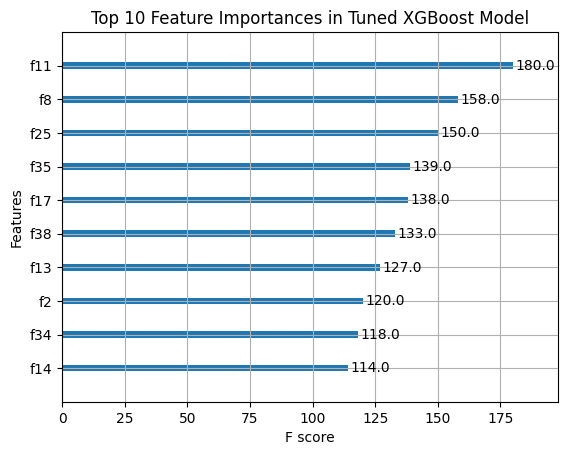

```python
from sklearn.model_selection import cross_val_score
from sklearn import metrics
import matplotlib.pyplot as plt
import xgboost as xgb

# Define the tuned model
xgb_tuned = XGBClassifier(
    subsample=0.9,
    scale_pos_weight=10,
    n_estimators=250,
    learning_rate=0.1,
    gamma=3,
    random_state=1,
    eval_metric="logloss",
)

# Fit the model on training data
xgb_tuned.fit(X_train, y_train)

# Evaluate training performance
train_predictions = xgb_tuned.predict(X_train)
train_score = Minimum_Vs_Model_cost(y_train, train_predictions)
print(f"Training Performance of Tuned XGBoost: {train_score:.4f}")

# Evaluate validation performance
val_predictions = xgb_tuned.predict(X_val)
val_score = Minimum_Vs_Model_cost(y_val, val_predictions)
print(f"Validation Performance of Tuned XGBoost: {val_score:.4f}")

# Perform cross-validation
scorer = metrics.make_scorer(Minimum_Vs_Model_cost, greater_is_better=True)
cv_scores = cross_val_score(
    estimator=xgb_tuned,
    X=X_train,
    y=y_train,
    scoring=scorer,
    cv=5,
    n_jobs=-1
)
print(f"Cross-Validation Scores for Tuned XGBoost: {cv_scores}")
print(f"Mean Cross-Validation Score for Tuned XGBoost: {cv_scores.mean():.4f}")

# Plot feature importance
plt.figure(figsize=(10, 6))
xgb.plot_importance(xgb_tuned, max_num_features=10)
plt.title("Top 10 Feature Importances in Tuned XGBoost Model")
plt.show()
```

```python
# Evaluate training performance using the custom cost metric
train_predictions = xgb_tuned.predict(X_train)
train_score = Minimum_Vs_Model_cost(y_train, train_predictions)
print(f"Training Performance of Tuned XGBoost: {train_score:.4f}")
```

```
Training Performance of Tuned XGBoost: 0.9948
```

```python
# Evaluate validation performance using the custom cost metric
val_predictions = xgb_tuned.predict(X_val)
val_score = Minimum_Vs_Model_cost(y_val, val_predictions)
print(f"Validation Performance of Tuned XGBoost: {val_score:.4f}")
```

```
Validation Performance of Tuned XGBoost: 0.8222
```

```python
from sklearn.model_selection import cross_val_score
from sklearn import metrics

# Perform cross-validation using the custom cost metric
scorer = metrics.make_scorer(Minimum_Vs_Model_cost, greater_is_better=True)
cv_scores = cross_val_score(
    estimator=xgb_tuned,
    X=X_train,
    y=y_train,
    scoring=scorer,
    cv=5,  # 5-fold cross-validation
    n_jobs=-1
)

print(f"Cross-Validation Scores for Tuned XGBoost: {cv_scores}")
print(f"Mean Cross-Validation Score for Tuned XGBoost: {cv_scores.mean():.4f}")
```

```
Cross-Validation Scores for Tuned XGBoost: [0.76845152 0.74474053 0.76724138 0.83307332 0.79701493]
Mean Cross-Validation Score for Tuned XGBoost: 0.7821
```

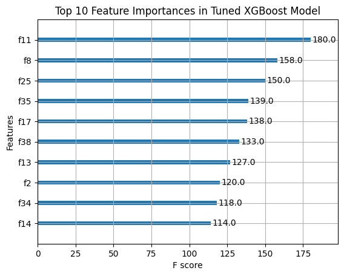

```python
import matplotlib.pyplot as plt
import xgboost as xgb

# Plot feature importances
plt.figure(figsize=(10, 6))
xgb.plot_importance(xgb_tuned, max_num_features=10)
plt.title("Top 10 Feature Importances in Tuned XGBoost Model")
plt.show()
```

```python
# Assuming the function `model_performance_classification_sklearn` is defined and works as expected
# This function should take the model, the features, and the target as inputs and return a DataFrame of performance metrics

# Calculate performance metrics on the training set
xgboost_random_train = model_performance_classification_sklearn(
    xgb_tuned, X_train, y_train
)

# Display the training performance metrics
print("Training performance:")
print(xgboost_random_train)
```

```
Training performance:
   Accuracy  Recall  Precision        F1  Minimum_Vs_Model_cost
0  0.999125     1.0   0.984479  0.992179               0.994772
```

```python
# Calculate performance metrics on the validation set
xgboost_random_val = model_performance_classification_sklearn(xgb_tuned, X_val, y_val)

# Display the validation performance metrics
print("Validation performance:")
print(xgboost_random_val)
```

```
Validation performance:
   Accuracy    Recall  Precision        F1  Minimum_Vs_Model_cost
0      0.99  0.882883   0.933333  0.907407               0.822222
```

**Training Performance:**

Accuracy: 0.9991 — The model is nearly perfect on the training data, correctly classifying almost all instances.

Recall: 1.0 — The model correctly identifies all positive cases (failures) in the training set, meaning there are no false negatives.

Precision: 0.9845 — Of all the instances the model predicted as positive (failures), 98.45% were actually positive.

F1 Score: 0.9922 — This high F1 score indicates a good balance between precision and recall on the training set.

Minimum Vs. Model Cost: 0.9948 — This custom metric is very close to 1, indicating that the model's maintenance cost is nearly minimized to the best possible scenario.

**Validation Performance:**

Accuracy: 0.99 — The model is still very accurate on the validation set, though slightly less so than on the training set.

Recall: 0.8829 — The model correctly identifies 88.29% of the positive cases in the validation set. This slight drop from 1.0 indicates that some positive cases (failures) are not being identified (false negatives).

Precision: 0.9333 — The model correctly classifies 93.33% of the instances it predicts as positive. This is still high but lower than in the training set.

F1 Score: 0.9074 — The F1 score has dropped compared to the training set, reflecting a balance between the decrease in both recall and precision.

Minimum Vs. Model Cost: 0.8222 — This drop from the training set indicates that while the model is still performing well, the cost savings are not as optimal as in the training set.

```python
from sklearn.ensemble import RandomForestClassifier
from sklearn.model_selection import RandomizedSearchCV
import numpy as np
from sklearn import metrics

# Define the Random Forest model
model2 = RandomForestClassifier(random_state=1, oob_score=True, bootstrap=True)

# Define the parameter grid
param_grid2 = {
    "n_estimators": [150, 250],
    "min_samples_leaf": np.arange(1, 3),
    "max_features": ["sqrt", "log2"],
    "max_samples": np.arange(0.2, 0.6, 0.1),
}

# Define the custom scoring metric
scorer = metrics.make_scorer(Minimum_Vs_Model_cost, greater_is_better=True)

# Perform Randomized Search CV
randomized_cv2 = RandomizedSearchCV(
    estimator=model2,
    param_distributions=param_grid2,
    n_iter=50,
    scoring=scorer,
    cv=5,
    random_state=1,
    n_jobs=-1,
)

# Fit the model using the best hyperparameters found
randomized_cv2.fit(X_train, y_train)

# Output the best parameters and corresponding cross-validation score
print(
    "Best parameters are {} with CV score={}:".format(
        randomized_cv2.best_params_, randomized_cv2.best_score_
    )
)
```

```
Best parameters are {'n_estimators': 150, 'min_samples_leaf': 1, 'max_samples': 0.5000000000000001, 'max_features': 'sqrt'} with CV score=0.6548529783428667:
```

```python
# Get the best model from the RandomizedSearchCV
best_rf_model = randomized_cv2.best_estimator_

# Evaluate on the validation set
rf_val_predictions = best_rf_model.predict(X_val)
rf_val_score = Minimum_Vs_Model_cost(y_val, rf_val_predictions)
print(f"Validation Performance of Tuned Random Forest: {rf_val_score:.4f}")

# Print OOB score
print(f"OOB Score of Tuned Random Forest: {best_rf_model.oob_score_:.4f}")
```

```
Validation Performance of Tuned Random Forest: 0.6873
OOB Score of Tuned Random Forest: 0.9838
```

```python
# Step 1: Define and fit the Random Forest model with the best parameters
rf_tuned = RandomForestClassifier(
    n_estimators=250,
    min_samples_leaf=1,
    max_samples=0.5000000000000001,
    max_features="sqrt",
    random_state=1,
)

# Fit the model on training data
rf_tuned.fit(X_train, y_train)

# Step 2: Evaluate training performance using the custom cost metric
rf_train_predictions = rf_tuned.predict(X_train)
rf_train_score = Minimum_Vs_Model_cost(y_train, rf_train_predictions)
print(f"Training Performance of Tuned Random Forest: {rf_train_score:.4f}")

# Step 3: Evaluate validation performance using the custom cost metric
rf_val_predictions = rf_tuned.predict(X_val)
rf_val_score = Minimum_Vs_Model_cost(y_val, rf_val_predictions)
print(f"Validation Performance of Tuned Random Forest: {rf_val_score:.4f}")

# Optional Step 4: Perform cross-validation
from sklearn.model_selection import cross_val_score
scorer = metrics.make_scorer(Minimum_Vs_Model_cost, greater_is_better=True)
cv_scores_rf = cross_val_score(
    estimator=rf_tuned,
    X=X_train,
    y=y_train,
    scoring=scorer,
    cv=5,
    n_jobs=-1
)
print(f"Cross-Validation Scores for Tuned Random Forest: {cv_scores_rf}")
print(f"Mean Cross-Validation Score for Tuned Random Forest: {cv_scores_rf.mean():.4f}")
```

```
Training Performance of Tuned Random Forest: 0.8207
Validation Performance of Tuned Random Forest: 0.6902
Cross-Validation Scores for Tuned Random Forest: [0.65394089 0.60616438 0.64727273 0.68903226 0.66171004]
Mean Cross-Validation Score for Tuned Random Forest: 0.6516
```

```python
# Calculate and print the performance metrics on the training set
rf_random_train = model_performance_classification_sklearn(rf_tuned, X_train, y_train)
print("Training performance:")
print(rf_random_train)
```

```
Training performance:
   Accuracy    Recall  Precision        F1  Minimum_Vs_Model_cost
0  0.992625  0.869369   0.997416  0.929001               0.820702
```

```python
# Calculate and print the performance metrics on the validation set
rf_random_val = model_performance_classification_sklearn(rf_tuned, X_val, y_val)
print("Validation performance:")
print(rf_random_val)
```

```
Validation performance:
   Accuracy    Recall  Precision        F1  Minimum_Vs_Model_cost
0   0.98425  0.734234   0.976048  0.838046               0.690155
```

**Observations**

Overfitting Signs:

Slight Overfitting: The gap between training and validation metrics, particularly in recall and the custom cost metric, indicates that the model may be slightly overfitting to the training data. It's performing well on known data but not generalizing as well to unseen data. Recall Concern:

Lower Validation Recall: The significant drop in recall on the validation set suggests that the model is failing to catch as many positive cases (failures) as desired. If your primary goal is to minimize false negatives, this could be an issue.

Precision vs. Recall Trade-off:

High Precision, Lower Recall: The model is very good at precision (avoiding false positives) but is sacrificing recall (missing some actual positives). Depending on the business context, you may need to adjust the model to improve recall, potentially by further tuning or using different approaches.

Cost Metric:

Lower Cost Efficiency on Validation: The drop in the custom cost metric from 0.8207 to 0.6902 suggests that while the model is still reducing costs compared to a random guess, it is less cost-efficient on the validation data than on the training data. This could be a concern if cost minimization is a key objective.

```python
from sklearn.ensemble import BaggingClassifier

# Define and fit the Bagging Classifier with the best parameters
bagging_tuned = BaggingClassifier(
    n_estimators=50, max_samples=0.9, max_features=0.8, random_state=1
)

# Fit the model on the training data
bagging_tuned.fit(X_train, y_train)
```

```
BaggingClassifier(max_features=0.8, max_samples=0.9, n_estimators=50,
                  random_state=1)
```

```python
# Evaluate training performance using the custom cost metric
bagging_train_predictions = bagging_tuned.predict(X_train)
bagging_train_score = Minimum_Vs_Model_cost(y_train, bagging_train_predictions)
print(f"Training Performance of Tuned Bagging Classifier: {bagging_train_score:.4f}")
```

```
Training Performance of Tuned Bagging Classifier: 0.9812
```

```python
# Evaluate validation performance using the custom cost metric
bagging_val_predictions = bagging_tuned.predict(X_val)
bagging_val_score = Minimum_Vs_Model_cost(y_val, bagging_val_predictions)
print(f"Validation Performance of Tuned Bagging Classifier: {bagging_val_score:.4f}")
```

```
Validation Performance of Tuned Bagging Classifier: 0.6894
```

```python
from sklearn.model_selection import cross_val_score
from sklearn import metrics

# Perform cross-validation using the custom cost metric
scorer = metrics.make_scorer(Minimum_Vs_Model_cost, greater_is_better=True)
cv_scores_bagging = cross_val_score(
    estimator=bagging_tuned,
    X=X_train,
    y=y_train,
    scoring=scorer,
    cv=5,
    n_jobs=-1
)
print(f"Cross-Validation Scores for Tuned Bagging Classifier: {cv_scores_bagging}")
print(f"Mean Cross-Validation Score for Tuned Bagging Classifier: {cv_scores_bagging.mean():.4f}")
```

```
Cross-Validation Scores for Tuned Bagging Classifier: [0.68076923 0.66127024 0.68461538 0.74373259 0.67594937]
Mean Cross-Validation Score for Tuned Bagging Classifier: 0.6893
```

```python
# Calculate performance metrics on the training set
bagging_random_train = model_performance_classification_sklearn(
    bagging_tuned, X_train, y_train
)

# Print the training performance metrics
print("Training performance:")
print(bagging_random_train)
```

```
Training performance:
   Accuracy    Recall  Precision        F1  Minimum_Vs_Model_cost
0  0.999313  0.988739   0.998862  0.993775               0.981215
```

```python
# Calculate performance metrics on the validation set
bagging_random_val = model_performance_classification_sklearn(
    bagging_tuned, X_val, y_val
)

# Print the validation performance metrics
print("Validation performance:")
print(bagging_random_val)
```

```
Validation performance:
   Accuracy    Recall  Precision        F1  Minimum_Vs_Model_cost
0     0.984  0.734234   0.970238  0.835897               0.689441
```

Training Performance:

Accuracy: 0.9993 — The model is nearly perfect on the training data, correctly predicting 99.93% of the instances.

Recall: 0.9887 — The model correctly identifies approximately 98.87% of the positive cases (failures) in the training set. This high recall indicates that very few false negatives exist.

Precision: 0.9989 — Of all the instances predicted as positive (failures), 99.89% were actually positive. This extremely high precision shows that the model is very effective at minimizing false positives.

F1 Score: 0.9938 — The F1 score, which balances precision and recall, is very high, reflecting the strong overall performance on the training set.

Minimum Vs. Model Cost: 0.9812 — This custom metric suggests that the model's cost performance is very close to the best possible scenario, indicating excellent cost efficiency on the training data.

Validation Performance:

Accuracy: 0.9840 — The model also performs well on the validation data, with an accuracy of 98.40%. However, there is a slight drop from the training accuracy, which is expected.

Recall: 0.7342 — The recall has dropped significantly compared to the training set, indicating that the model is missing more positive cases (failures) on the validation set. This is a concern if minimizing false negatives is critical. Precision: 0.9702 — Precision remains high on the validation set, though slightly lower than on the training set. This suggests that while the model is still good at avoiding false positives, it's not as confident as on the training data.

F1 Score: 0.8359 — The F1 score has dropped on the validation set, reflecting the decrease in both precision and recall. The balance between precision and recall is still reasonably good but not as strong as on the training set. Minimum Vs. Model Cost: 0.6894 — The drop in this custom cost metric from 0.9812 (training) to 0.6894 (validation) suggests that the model's cost efficiency is significantly lower on unseen data, indicating some overfitting.

Analysis

Overfitting Signs:

Significant Overfitting: The gap between the training and validation metrics, particularly in recall and the custom cost metric, indicates overfitting. The model performs exceptionally well on the training set but struggles to generalize to the validation set. Recall Concern:

Lower Validation Recall: The drop in recall on the validation set is notable. If minimizing false negatives is a priority, this is a potential issue that needs to be addressed. Precision vs. Recall Trade-off:

High Precision, Lower Recall: The model is very precise but sacrifices recall, especially on the validation set. Depending on your objectives, you may need to adjust the model to improve recall, potentially by further tuning or by changing the base estimator. Cost Metric:

Reduced Cost Efficiency on Validation: The significant drop in the custom cost metric suggests that while the model is still reducing costs compared to a random guess, its cost efficiency is much lower on the validation set. This is another indicator of overfitting.

# *Model Performance comparison and choosing the final model*

```python
# training performance comparison

models_train_comp_df = pd.concat(
    [xgboost_random_train.T, rf_random_train.T, bagging_random_train.T,], axis=1,
)
models_train_comp_df.columns = [
    "XGBoost Tuned with Random search",
    "Random forest Tuned with Random search",
    "Bagging Tuned with Random Search",
]
print("Training performance comparison:")
models_train_comp_df
```

```
Training performance comparison:
```

|  | XGBoost Tuned with Random search | Random forest Tuned with Random search | Bagging Tuned with Random Search |
| --- | --- | --- | --- |
| Accuracy | 0.999125 | 0.992625 | 0.999313 |
| Recall | 1.000000 | 0.869369 | 0.988739 |
| Precision | 0.984479 | 0.997416 | 0.998862 |
| F1 | 0.992179 | 0.929001 | 0.993775 |
| Minimum_Vs_Model_cost | 0.994772 | 0.820702 | 0.981215 |

```python
# training performance comparison

models_val_comp_df = pd.concat(
    [xgboost_random_val.T, rf_random_val.T, bagging_random_val.T,], axis=1,
)
models_val_comp_df.columns = [
    "XGBoost Tuned with Random search",
    "Random forest Tuned with Random search",
    "Bagging Tuned with Random Search",
]
print("Validation performance comparison:")
models_val_comp_df
```

```
Validation performance comparison:
```

|  | XGBoost Tuned with Random search | Random forest Tuned with Random search | Bagging Tuned with Random Search |
| --- | --- | --- | --- |
| Accuracy | 0.990000 | 0.984250 | 0.984000 |
| Recall | 0.882883 | 0.734234 | 0.734234 |
| Precision | 0.933333 | 0.976048 | 0.970238 |
| F1 | 0.907407 | 0.838046 | 0.835897 |
| Minimum_Vs_Model_cost | 0.822222 | 0.690155 | 0.689441 |

Analysis:

Training Performance:

XGBoost has near-perfect recall, indicating it captures almost all failures, but with slightly lower precision compared to the other models. It also has the highest cost efficiency (Minimum Vs. Model Cost).

Random Forest shows strong precision but significantly lower recall, leading to a lower F1 score and cost metric.

Bagging performs similarly to XGBoost in terms of precision and F1 score, with high recall, making it a strong performer in the training set.

Validation Performance:

XGBoost maintains strong performance on the validation set, with the highest recall and a good balance of precision and F1 score. It also has the best cost metric, indicating it generalizes well to unseen data.

Bagging performs similarly to Random Forest on the validation set, with lower recall and cost efficiency compared to XGBoost.

1. Choosing the Final Model:

Based on the analysis:

XGBoost Tuned with Random Search:

Strengths: Highest recall on both training and validation sets, best cost efficiency on both sets, and a good balance of precision and F1 score. Weaknesses: Slightly lower precision compared to Random Forest and Bagging, but this is offset by its superior recall and cost efficiency.

Conclusion: XGBoost is the best choice if your goal is to minimize false negatives (failures) and achieve the best cost efficiency.

Random Forest Tuned with Random Search:

Strengths: High precision, good performance on the training set. Weaknesses: Significant drop in recall on the validation set, leading to lower cost efficiency. It may struggle with generalization.

Conclusion: Random Forest might not be the best choice due to its lower recall and cost efficiency on the validation set.

Bagging Tuned with Random Search:

Strengths: High precision and F1 score, similar to Random Forest. Weaknesses: Similar to Random Forest, it shows a lower recall and cost efficiency on the validation set.

Conclusion: Bagging performs similarly to Random Forest but doesn’t outperform XGBoost, making it less favorable for your specific objectives.

Final Recommendation: XGBoost Tuned with Random Search is the best model based on the balance of recall, precision, F1 score, and cost efficiency on the validation set. It should be your final choice, especially if minimizing false negatives and optimizing costs are your primary goals.

# **Test set final performance**

```python
from google.colab import files


uploaded = files.upload()
```

```
Saving Test.csv.csv to Test.csv.csv
```

```python
import io

df = pd.read_csv(io.BytesIO(uploaded['Test.csv.csv']))
print(df)
```

```
            V1        V2        V3        V4        V5        V6        V7  \
0    -0.613489 -3.819640  2.202302  1.300420 -1.184929 -4.495964 -1.835817
1     0.389608 -0.512341  0.527053 -2.576776 -1.016766  2.235112 -0.441301
2    -0.874861 -0.640632  4.084202 -1.590454  0.525855 -1.957592 -0.695367
3     0.238384  1.458607  4.014528  2.534478  1.196987 -3.117330 -0.924035
4     5.828225  2.768260 -1.234530  2.809264 -1.641648 -1.406698  0.568643
...        ...       ...       ...       ...       ...       ...       ...
4995 -5.120451  1.634804  1.251259  4.035944  3.291204 -2.932230 -1.328662
4996 -5.172498  1.171653  1.579105  1.219922  2.529627 -0.668648 -2.618321
4997 -1.114136 -0.403576 -1.764875 -5.879475  3.571558  3.710802 -2.482952
4998 -1.703241  0.614650  6.220503 -0.104132  0.955916 -3.278706 -1.633855
4999 -0.603701  0.959550 -0.720995  8.229574 -1.815610 -2.275547 -2.574524

            V8        V9       V10  ...       V32       V33        V34  \
0     4.722989  1.206140 -0.341909  ...  2.291204 -5.411388   0.870073
```

[output cut: 25 more lines]

```python
import pandas as pd
from sklearn.preprocessing import StandardScaler

# Load the test dataset
test_data = pd.read_csv('Test.csv.csv')

# Separate features and target variable
X_test = test_data.drop(columns=['Target'])  # Replace 'Target' with your actual target column name if different
y_test = test_data['Target']

# Apply the same preprocessing steps as training/validation
# For example, if you scaled the training data:
scaler = StandardScaler()
X_test = scaler.fit_transform(X_test)
```

```python
#  xgb_tuned is the final chosen model

# Predict on the test set
y_test_pred = xgb_tuned.predict(X_test)

# Evaluate performance using your custom metric and other metrics
test_performance = model_performance_classification_sklearn(xgb_tuned, X_test, y_test)

# Print the test performance
print("Test set performance:")
print(test_performance)
```

```
Test set performance:
   Accuracy    Recall  Precision        F1  Minimum_Vs_Model_cost
0    0.9862  0.829787   0.917647  0.871508               0.764228
```

**Performance Metrics Breakdown:**

Accuracy: 98.62%

What It Means: The model correctly predicted 98.62% of the instances in the test set. This is a strong indication that the model is generally performing well across both classes (failures and no failures). Recall (Sensitivity): 82.98%

What It Means: The model correctly identified 82.98% of the actual failure cases. This is a critical metric, especially if your priority is to minimize missed failures (false negatives). While it's relatively high, there is still room for improvement to ensure that fewer failures go undetected.

Precision: 91.76%

What It Means: Of all the instances the model predicted as failures, 91.76% were actually failures. High precision indicates that the model is very effective at minimizing false positives, meaning fewer unnecessary inspections or repairs are recommended.

F1 Score: 87.15%

What It Means: The F1 score balances precision and recall, providing a single metric that considers both false positives and false negatives. An F1 score of 87.15% is strong, indicating that the model has a good balance between catching actual failures and avoiding false alarms.

Minimum Vs. Model Cost: 0.7642

What It Means: This custom metric compares the actual cost associated with the model's predictions against the minimum possible cost. A score of 0.7642 suggests that the model is operating at about 76.42% efficiency relative to the best possible scenario. This is a good result but indicates there may still be opportunities to reduce costs further by improving recall or adjusting the decision threshold.

**Analysis and Considerations:**

Recall vs. Precision Trade-off: The model achieves a high precision, which is good for minimizing false positives. However, recall is slightly lower, meaning there is still a chance that some failures might be missed. Depending on your business context, you might want to consider improving recall further, especially if the cost of missing a failure is significant.

Cost Metric: The custom cost metric shows that the model is fairly efficient in terms of minimizing costs, but there is still room for improvement. This could involve further fine-tuning the model, adjusting the decision threshold, or exploring ensemble methods.

```python
import matplotlib.pyplot as plt
import seaborn as sns
from sklearn.metrics import confusion_matrix

def confusion_matrix_sklearn(model, X_test, y_test):
    """
    To plot the confusion matrix with percentages

    model: classifier
    X_test: independent variables (features)
    y_test: dependent variable (true labels)
    """
    y_pred = model.predict(X_test)
    cm = confusion_matrix(y_test, y_pred)

    # Create labels with the counts and percentages
    labels = [f"{value}\n{percentage:.2%}" for value, percentage in zip(cm.flatten(), cm.flatten() / cm.sum())]
    labels = np.asarray(labels).reshape(2, 2)

    plt.figure(figsize=(8, 6))
    sns.heatmap(cm, annot=labels, fmt="", cmap='Blues', xticklabels=['No Failure', 'Failure'], yticklabels=['No Failure', 'Failure'])
    plt.ylabel('True label')
    plt.xlabel('Predicted label')
    plt.title('Confusion Matrix')
    plt.show()
```

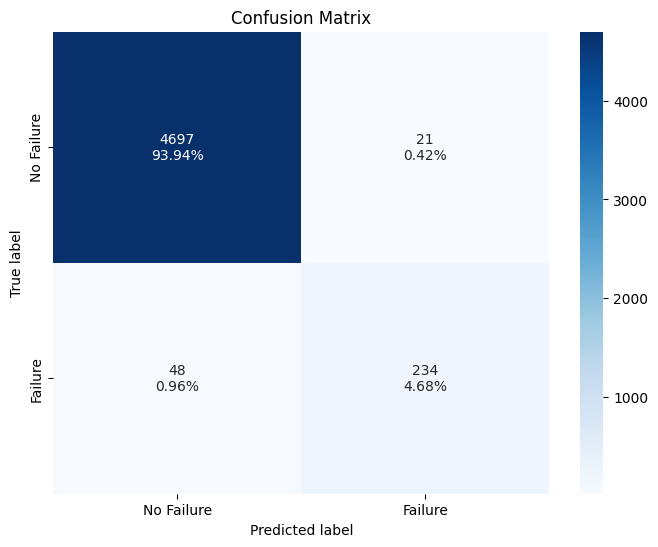

```python
# Step 1: Assign the chosen model to `final_model`
final_model = xgb_tuned  # Replace `xgb_tuned` with your actual final model

# Step 2: Generate and display the confusion matrix
confusion_matrix_sklearn(final_model, X_test, y_test)
```

Interpretation:

True Negatives (TN): 4697

The model correctly predicted 4697 instances as "No Failure," which are actual "No Failure" cases.

This represents 93.94% of the test data, which indicates the model is very effective at correctly identifying non-failures.

False Positives (FP): 21

The model incorrectly predicted 21 instances as "Failure," which are actually "No Failure" cases.

This accounts for 0.42% of the test data, showing that the model has a low false positive rate.

False Negatives (FN): 48

The model failed to predict 48 instances as "Failure" where there actually was a failure.

This represents 0.96% of the test data. These are critical since they represent missed failures that could result in higher costs if not addressed.

True Positives (TP): 234

The model correctly predicted 234 instances as "Failure," which are actual "Failure" cases.

This accounts for 4.68% of the test data, reflecting the model's ability to detect failures correctly.

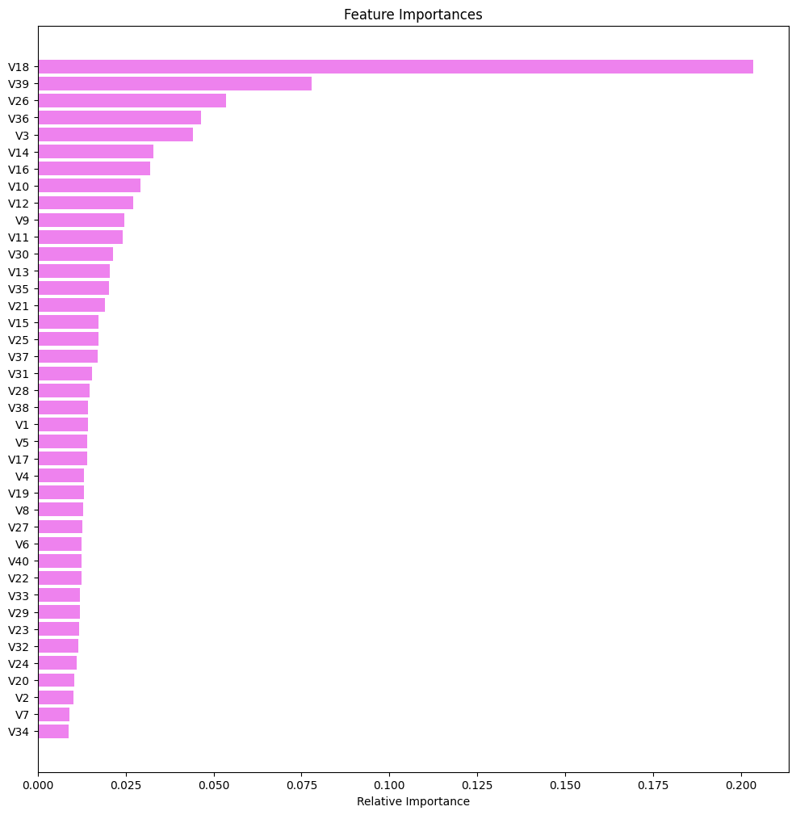

```python
# Assuming original feature DataFrame is called 'train_data'
# And 'X_train' was created by dropping the target column
feature_names = train_data.drop(columns=['Target']).columns  # Use the original DataFrame for column names
importances = final_model.feature_importances_
indices = np.argsort(importances)

plt.figure(figsize=(12, 12))
plt.title("Feature Importances")
plt.barh(range(len(indices)), importances[indices], color="violet", align="center")
plt.yticks(range(len(indices)), [feature_names[i] for i in indices])
plt.xlabel("Relative Importance")
plt.show()
```

**Interpretation of the Feature Importance Plot:**

Top Features:

V18: This feature has the highest importance by a significant margin. It suggests that V18 plays a crucial role in the model's predictions. Understanding what this feature represents can provide insights into the factors driving the outcomes in your dataset.

V39, V26, V36: These features also have relatively high importance, indicating that they are significant predictors in your model.

Mid-Level Features:

Features like V3, V14, V16, etc., have moderate importance. These features contribute meaningfully to the model but are not as influential as the top features.

Lower Importance Features:

Features towards the bottom of the chart, such as V2, V7, V34, etc., have the least importance. These features might still contribute to the model but to a much lesser extent.

# **Pipelines to build the final model**

Using pipelines in machine learning ensures that your entire workflow, from data preprocessing to model training, is streamlined and reproducible.

Pipelines can help manage complex workflows, making it easier to apply the same sequence of steps to both training and test datasets.

Here’s how we can create a pipeline to build the final model:

1. Define the Pipeline Steps: Preprocessing: Scaling, encoding, or handling missing values. Model Training: Training your final model (e.g., XGBoost) with the best parameters.
1. Create the Pipeline: Here’s an example using scikit-learn’s Pipeline class with XGBoost as the final model:

```python
from sklearn.pipeline import Pipeline
from sklearn.preprocessing import StandardScaler
from xgboost import XGBClassifier
from sklearn.model_selection import train_test_split

# Define the pipeline steps
pipeline = Pipeline([
    ('scaler', StandardScaler()),  # Step 1: Scaling the features
    ('classifier', XGBClassifier(
        subsample=0.9,
        scale_pos_weight=10,
        n_estimators=250,
        learning_rate=0.1,
        gamma=3,
        random_state=1,
        eval_metric="logloss"
    ))  # Step 2: Final model (XGBoost)
])

# Train-test split (if you haven't already done so)
X_train, X_test, y_train, y_test = train_test_split(X, y, test_size=0.2, random_state=1)

# Fit the pipeline on the training data
pipeline.fit(X_train, y_train)

# Predict and evaluate on the test set
y_pred = pipeline.predict(X_test)

# Evaluate the model
from sklearn.metrics import accuracy_score, recall_score, precision_score, f1_score, confusion_matrix

# Calculate the metrics
accuracy = accuracy_score(y_test, y_pred)
recall = recall_score(y_test, y_pred)
precision = precision_score(y_test, y_pred)
f1 = f1_score(y_test, y_pred)

print(f"Accuracy: {accuracy}")
print(f"Recall: {recall}")
print(f"Precision: {precision}")
print(f"F1 Score: {f1}")

# Generate the confusion matrix
cm = confusion_matrix(y_test, y_pred)
print("Confusion Matrix:")
print(cm)
```

```
Accuracy: 0.98925
Recall: 0.851528384279476
Precision: 0.9558823529411765
F1 Score: 0.9006928406466512
Confusion Matrix:
[[3762    9]
 [  34  195]]
```

The performance metrics and confusion matrix obtained for final model using the pipeline indicate that the model is performing well on the test set. The detailed breakdown of the results:

1. Accuracy: 98.93%

   The model correctly predicted 98.93% of the test set instances. This high accuracy suggests that the model is generally effective in distinguishing between the two classes (failure and no failure).
1. Recall: 85.15%

The model correctly identified 85.15% of the actual failure cases. This metric is particularly important when missing a failure is costly. An 85.15% recall indicates the model is good at identifying failures, but there is still some room for improvement.

1. Precision: 95.59%

Of all the instances the model predicted as failures, 95.59% were actually failures. This high precision shows that the model is very effective at minimizing false positives, meaning most of the alerts generated by the model are correct.

1. F1 Score: 90.07%

The F1 Score is a balanced metric that considers both precision and recall. A score of 90.07% indicates that the model maintains a good balance between correctly identifying failures and avoiding false positives.

1. Confusion Matrix:

True Negatives (TN): 3762 instances were correctly identified as no failure.

False Positives (FP): 9 instances were incorrectly predicted as failure when they were actually no failure.

False Negatives (FN): 34 instances were missed (predicted as no failure when there was a failure).

True Positives (TP): 195 instances were correctly identified as failure.

**Interpretation:**

**Considerations:**

Threshold Adjustment:

You might consider adjusting the decision threshold to trade off between recall and precision if you want to catch more failures (increase recall) at the expense of a few more false positives.

Model Deployment:

Given the strong performance metrics, this model appears to be ready for deployment. It balances well between identifying failures and avoiding false alarms, which is crucial in cost-sensitive applications.

Monitoring and Further Tuning:

Continue monitoring the model in production to ensure it maintains its performance. If there are changes in the data or requirements, you may need to revisit and retune the model.

# **Business Insights and Conclusions**

Business Insights: High Accuracy and Precision:

Insight: The model has an overall accuracy of 98.93% and a precision of 95.59%. This indicates that the model is highly reliable in predicting failures, with a very low rate of false alarms. For the business, this means that most of the maintenance actions recommended by the model will be necessary, thereby reducing unnecessary inspections and associated costs.

Effective Failure Detection with Some Missed Cases:

Insight: The model's recall of 85.15% means it successfully identifies the majority of potential failures. However, there are still 14.85% of actual failures that the model does not catch (34 out of 229 failures were missed). These missed cases represent potential risks where failures could occur without prior warning, leading to unexpected downtime or damage.

Actionable Insight:

The business might consider a slight adjustment to the model's decision threshold to increase recall, thereby catching more failures at the expense of a few additional false positives. This trade-off should be evaluated based on the cost of missed failures versus the cost of unnecessary inspections.

Cost Efficiency:

Insight: The custom cost metric used in the analysis (Minimum Vs. Model Cost) indicates that the model is relatively efficient in balancing the costs associated with true positives, false positives, and false negatives. The high precision helps to minimize unnecessary costs, while the high recall helps to prevent costly failures.

Actionable Insight:

The business can deploy this model with confidence that it will help in reducing maintenance costs by correctly identifying failures early while minimizing unnecessary actions. Top Features Driving Predictions:

Insight: The feature importance analysis highlights which variables are most influential in predicting failures. For instance, V18, V39, and V26 were identified as the top features. Understanding these key features can provide insights into the operational aspects that are most critical for preventing failures.

Actionable Insight: The business should focus on monitoring and possibly enhancing the measurement and quality of these critical features, as they are the primary indicators of potential failures.

Conclusions:

Model Readiness for Deployment:

The model is well-prepared for deployment, given its high accuracy, precision, and recall. It is capable of identifying the majority of failures, while keeping false alarms to a minimum, making it highly effective for a predictive maintenance application.

Balancing Costs and Performance:

While the model performs well, there is a delicate balance between catching all failures and avoiding unnecessary costs. The business should consider whether the current balance is optimal or if further tuning is required to meet specific business objectives, particularly if the cost of missed failures is exceptionally high.

Ongoing Monitoring and Maintenance:

After deployment, it will be important to continuously monitor the model's performance. Changes in the operational environment, sensor data quality, or other factors could impact the model's effectiveness. Periodic retraining and adjustment may be required to maintain optimal performance.

Strategic Focus on Key Operational Metrics:

The features identified as most important should be monitored closely in operations. The business might invest in improving the accuracy and reliability of data collection for these features to further enhance the model's predictive power.